# 1 Appendix S1 - Functions

This script includes the functions “tetra”, “tri” and “di” which compute chromatic coordinates in visual space for tetra-, tri- and di-chromatic visual systems respectively. These scripts need to be run before those detailed in Appendices S2-S5. Note that in order to run these functions you need to have the packages “plyr” and “reshape2” installed.

It also contains the functions “cov.Mtest” and “meanTest” used to compare covariance matrices (Box’s M test by Michail Tsagris) and multivariate means respectively. Their use is described in Appendix S5.

## 1.1 Function “tetra”

function (Refl, Irr, Tetra, pcones = NULL, weber = NULL, doubleCone = NULL, wLong = 0.05, idVars = NULL, wlRefl = NULL, wlIrr = 1, irrIrr = 2, wlTetra = 1, conesTetra = 2:5, wlDoubleCone = 1, sensDoubleCone = 2, wlInclude = TRUE)

*Arguments* (similar arguments apply to functions “tri” and “di”)

*Refl:*  
Reflectance data.frame in wide format: observations in rows and reflectances in columns, one for each focal wavelength; typically including also ID variables. Reflectance columns should begin with “wl” followed by the corresponding wavelength value in nm, e.g.: “wl300”, …, “wl700”. Other columns are treated by default as ID variables. See idVars and wlRefl to change this behaviour.

*Irr:*  
Irradiance data.frame. By default, tetra() assumes that wavelength values are stored in the first column, and irradiances in the second column. See irrWl and irrIrr to change default settings.

*Tetra:*  
data.frame of cone sensitivities of a tetrachromatic eye. By default, tetra() assumes that wavelength values are stored in the first column, and that columns 2 to 5 store cone sensitivities to very short (VS), short (S), medium (M) and long (L) wavelengths respectively. See wlTetra and conesTetra to change default settings.

*pcones:*  
vector of cone proportions of VS, S, M and L cones, expressed relative to the L cone.

*Weber:* vector of Weber fractions, overrides WLong and pcones.

*doubleCone:*  
data.frame with double cones sensitivities. By default, tetra() assumes that wavelength values are stored in the first column, and sensitivities in the second column. See wlDoubleCone and sensDoubleCone to change default settings.

*wLong* Weber fraction of the L cone

*idVars*  
names or indices of ID variables in Refl. When idVars=NULL, all variable names not starting with “wl” are considered ID variables.

*wlRefl*  
names or indices of columns which store reflectance values in Refl. When wlRefl=NULL, column names starting with “wl” are taken as reflectance values.

*wlIrr* name or index of column which stores wavelengths values in Irr

*irrIrr*  
name or index of column which stores irradiances values in Irr

*wlTetra*  
name or index of column which stores wavelengths values in Tetra

*conesTetra*  
names or indices of columns which store cone’s sensitivities in Tetra

*wlDoubleCone*  
name or index of column which stores wavelengths values in DoubleCone

*sensDoubleCone*  
name or index of column which stores cone sensitivities in DoubleCone

*wlInclude* logical, should Refl reflectances be included in the output?

```r
#copy and paste into your R console to run these scripts first

tetra<-function (Refl, Irr, Tetra, pcones = NULL, weber = NULL, doubleCone = NULL,
    wLong = 0.05, idVars = NULL, wlRefl = NULL, wlIrr = 1, irrIrr = 2,
    wlTetra = 1, conesTetra = 2:5, wlDoubleCone = 1, sensDoubleCone = 2,
    wlInclude = TRUE)
{
    require(plyr)
    require(reshape2)
    IrrArg <- deparse(substitute(Irr))
    irrName <- names(Irr)[names(Irr) == names(Irr[irrIrr])]
    TetraArg <- deparse(substitute(Tetra))
    if (is.null(idVars)) {
        idVars <- names(Refl)[!(gsub("[[:digit:]]", "", names(Refl)) %in%
            "wl")]
    }
    if (is.null(wlRefl)) {
        wlRefl <- names(Refl)[gsub("[[:digit:]]", "", names(Refl)) %in%
            "wl"]
    }
    idRefl <- Refl[idVars]
    dfRefl <- Refl[wlRefl]
    ReflWl <- as.numeric(gsub("[[:punct:]]", "", gsub("[[:alpha:]]",
        "", names(dfRefl))))
    names(Irr)[names(Irr) == names(Irr[wlIrr])] <- "wl"
    names(Irr)[names(Irr) == names(Irr[irrIrr])] <- "irr"
    names(Tetra)[names(Tetra) == names(Tetra[wlTetra])] <- "wl"
    names(Tetra)[conesTetra] <- c("VS", "S", "M", "L")
    commonWL <- Reduce(intersect, list(round(Irr$wl), round(Tetra$wl),
        round(ReflWl)))
    if (!is.null(doubleCone)) {
        names(doubleCone)[names(doubleCone) == names(doubleCone[wlDoubleCone])] <- "wl"
        names(doubleCone)[names(doubleCone) == names(doubleCone[sensDoubleCone])] <- "sens"
        commonWL <- intersect(commonWL, round(doubleCone$wl))
        doubleCone <- doubleCone[round(doubleCone$wl) %in% commonWL,
            ]
    }
    Irr <- Irr[round(Irr$wl) %in% commonWL, ]
    Tetra <- Tetra[round(Tetra$wl) %in% commonWL, ]
    dfRefl <- dfRefl[, round(ReflWl) %in% commonWL]
    reso <- unique(diff(Irr$wl))
    matrixRefl <- as.matrix(dfRefl)
    if (!is.null(doubleCone)) {
        irrDC <- cbind(doubleCone$sens) * Irr$irr
        dcCatch <- c((matrixRefl %*% irrDC) * reso)
    }
    irrcones <- as.matrix(Tetra[, c("VS", "S", "M", "L")] * Irr$irr)
    Tcatch <- (matrixRefl %*% irrcones) * reso
    if (!is.null(pcones) | !is.null(weber)) {
        if (!is.null(pcones)) {
            W <- (wLong/sqrt(pcones))^2
        }
        if (!is.null(weber)) {
            W <- weber
        }
        H <- c(1/sqrt(W[1] + W[2]), sqrt((W[1] + W[2])/(W[1] *
            W[2] + W[1] * W[3] + W[2] * W[3])), sqrt((W[1] *
            W[2] + W[1] * W[3] + W[2] * W[3])/(W[1] * W[2] *
            W[3] + W[1] * W[2] * W[4] + W[1] * W[3] * W[4] +
            W[2] * W[3] * W[4])))
        h <- c(W[2]/(W[1] + W[2]), W[1]/(W[1] + W[2]), W[2] *
            W[3]/(W[1] * W[2] + W[2] * W[3] + W[1] * W[3]), W[1] *
            W[3]/(W[1] * W[2] + W[2] * W[3] + W[1] * W[3]), W[1] *
            W[2]/(W[1] * W[2] + W[2] * W[3] + W[1] * W[3]))
        TcatchTot <- apply(Tcatch, 1, sum)
        lcr <- log(Tcatch/matrix(rep(TcatchTot, 4), ncol = 4))
        x <- H[1] * (lcr[, 1] - lcr[, 2])
        y <- H[2] * (lcr[, 3] - (h[1] * lcr[, 1] + h[2] * lcr[,
            2]))
        z <- H[3] * (lcr[, 4] - (h[3] * lcr[, 1] + h[4] * lcr[,
            2] + h[5] * lcr[, 3]))
    }
    out <- data.frame(idRefl, wlResol = reso, Irr = paste(IrrArg,
        irrName, sep = "$"), Tetra = TetraArg)
    if (!is.null(pcones)) {
        out <- data.frame(out, conesProp = paste(round(pcones,
            2), collapse = ","))
    }
    if (!is.null(pcones) | !is.null(weber)) {
        out <- data.frame(out, WeberFrac = paste(round(sqrt(W), 4),
            collapse = ","))
    }
    out <- data.frame(out, Tcatch)
    if (!is.null(doubleCone)) {
        out <- data.frame(out, DC = dcCatch)
    }
    if (!is.null(pcones) | !is.null(weber)) {
        out <- data.frame(out, x = x, y = y, z = z)
    }
    if (wlInclude) {
        out <- cbind(out, dfRefl)
    }
    out
}
```

## 1.2 Function “tri”

```r
#copy and paste into your R console to run these scripts first

tri<-function (Refl, Irr, Tri, pcones = NULL, weber = NULL, wLong = 0.05,
    idVars = NULL, wlRefl = NULL, wlIrr = 1, irrIrr = 2, wlTri = 1,
    conesTri = 2:4, wlInclude = TRUE)
{
    require(plyr)
    require(reshape2)
    IrrArg <- deparse(substitute(Irr))
    irrName <- names(Irr)[names(Irr) == names(Irr[irrIrr])]
    TriArg <- deparse(substitute(Tri))
    if (is.null(idVars)) {
        idVars <- names(Refl)[!(gsub("[[:digit:]]", "", names(Refl)) %in%
            "wl")]
    }
    if (is.null(wlRefl)) {
        wlRefl <- names(Refl)[gsub("[[:digit:]]", "", names(Refl)) %in%
            "wl"]
    }
    idRefl <- Refl[idVars]
    dfRefl <- Refl[wlRefl]
    ReflWl <- as.numeric(gsub("[[:punct:]]", "", gsub("[[:alpha:]]",
        "", names(dfRefl))))
    names(Irr)[names(Irr) == names(Irr[wlIrr])] <- "wl"
    names(Irr)[names(Irr) == names(Irr[irrIrr])] <- "irr"
    names(Tri)[names(Tri) == names(Tri[wlTri])] <- "wl"
    names(Tri)[conesTri] <- c("S", "M", "L")
    commonWL <- Reduce(intersect, list(round(Irr$wl), round(Tri$wl),
        round(ReflWl)))
    Irr <- Irr[round(Irr$wl) %in% commonWL, ]
    Tri <- Tri[round(Tri$wl) %in% commonWL, ]
    dfRefl <- dfRefl[, round(ReflWl) %in% commonWL]
    reso <- unique(diff(Irr$wl))
    matrixRefl <- as.matrix(dfRefl)
    irrcones <- as.matrix(Tri[, c("S", "M", "L")] * Irr$irr)
    Tcatch <- (matrixRefl %*% irrcones) * reso
    if (!is.null(pcones) | !is.null(weber)) {
        if (!is.null(pcones)) {
            W <- (wLong/sqrt(pcones))^2
        }
        if (!is.null(weber)) {
            W <- weber
        }
        H <- c(1/sqrt(W[1] + W[2]), sqrt((W[1] + W[2])/(W[1] *
            W[2] + W[1] * W[3] + W[2] * W[3])))
        h <- c(W[2]/(W[1] + W[2]), W[1]/(W[1] + W[2]))
        TcatchTot <- apply(Tcatch, 1, sum)
        lcr <- log(Tcatch/matrix(rep(TcatchTot, 3), ncol = 3))
        x <- H[1] * (lcr[, 1] - lcr[, 2])
        y <- H[2] * (lcr[, 3] - (h[1] * lcr[, 1] + h[2] * lcr[,
            2]))
    }
    out <- data.frame(idRefl, wlResol = reso, Irr = paste(IrrArg,
        irrName, sep = "$"), Tri = TriArg)
    if (!is.null(pcones)) {
        out <- data.frame(out, conesProp = paste(round(pcones,
            2), collapse = ","))
    }
    if (!is.null(pcones) | !is.null(weber)) {
        out <- data.frame(out, WeberFrac = paste(round(sqrt(W), 4),
            collapse = ","))
    }
    out <- data.frame(out, Tcatch)
    if (!is.null(pcones) | !is.null(weber)) {
        out <- data.frame(out, x = x, y = y)
    }
    if (wlInclude) {
        out <- cbind(out, dfRefl)
    }
    out
}
```

## 1.3 Function “di”

```r
#copy and paste into your R console to run these scripts first

di<-function (Refl, Irr, Bi, pcones = NULL, weber = NULL, wLong = 0.05,
    idVars = NULL, wlRefl = NULL, wlIrr = 1, irrIrr = 2, wlBi = 1,
    conesBi = 2:3, wlInclude = TRUE)
{
    require(plyr)
    require(reshape2)
    IrrArg <- deparse(substitute(Irr))
    irrName <- names(Irr)[names(Irr) == names(Irr[irrIrr])]
    BiArg <- deparse(substitute(Bi))
    if (is.null(idVars)) {
        idVars <- names(Refl)[!(gsub("[[:digit:]]", "", names(Refl)) %in%
            "wl")]
    }
    if (is.null(wlRefl)) {
        wlRefl <- names(Refl)[gsub("[[:digit:]]", "", names(Refl)) %in%
            "wl"]
    }
    idRefl <- Refl[idVars]
    dfRefl <- Refl[wlRefl]
    ReflWl <- as.numeric(gsub("[[:punct:]]", "", gsub("[[:alpha:]]",
        "", names(dfRefl))))
    names(Irr)[names(Irr) == names(Irr[wlIrr])] <- "wl"
    names(Irr)[names(Irr) == names(Irr[irrIrr])] <- "irr"
    names(Bi)[names(Bi) == names(Bi[wlBi])] <- "wl"
    names(Bi)[conesBi] <- c("S", "L")
    commonWL <- Reduce(intersect, list(round(Irr$wl), round(Bi$wl),
        round(ReflWl)))
    Irr <- Irr[round(Irr$wl) %in% commonWL, ]
    Bi <- Bi[round(Bi$wl) %in% commonWL, ]
    dfRefl <- dfRefl[, round(ReflWl) %in% commonWL]
    reso <- unique(diff(Irr$wl))
    matrixRefl <- as.matrix(dfRefl)
    irrcones <- as.matrix(Bi[, c("S", "L")] * Irr$irr)
    Tcatch <- (matrixRefl %*% irrcones) * reso
    if (!is.null(pcones) | !is.null(weber)) {
        if (!is.null(pcones)) {
            W <- (wLong/sqrt(pcones))^2
        }
        if (!is.null(weber)) {
            W <- weber
        }
        H <- c(1/sqrt(W[1] + W[2]))
        TcatchTot <- apply(Tcatch, 1, sum)
        lcr <- log(Tcatch/matrix(rep(TcatchTot, 2), ncol = 2))
        x <- H[1] * (lcr[, 1] - lcr[, 2])
    }
    out <- data.frame(idRefl, wlResol = reso, Irr = paste(IrrArg,
        irrName, sep = "$"), Bi = BiArg)
    if (!is.null(pcones)) {
        out <- data.frame(out, conesProp = paste(round(pcones,
            2), collapse = ","))
    }
    if (!is.null(pcones) | !is.null(weber)) {
        out <- data.frame(out, WeberFrac = paste(round(sqrt(W), 4),
            collapse = ","))
    }
    out <- data.frame(out, Tcatch)
    if (!is.null(pcones) | !is.null(weber)) {
        out <- data.frame(out, x = x)
    }
    if (wlInclude) {
        out <- cbind(out, dfRefl)
    }
    out
}
```

## 1.4 Function “cov.Mtest” by Michail Tsagris

```r
#BOx's M test for the equality of covariance matrices
#by Michail Tsagris from http://www.academia.edu/1887808/Multivariate_statistical_functions_in_R

cov.Mtest=function(x,ina,a=0.05) {
  ## x is the data set
  ## ina is a numeric vector indicating the groups of the data set
  ## a is the significance level, set to 0.05 by default
  x=as.matrix(x)
  p=ncol(x)   ## dimension of the data
  n=nrow(x)   ## total sample size
  k=max(ina)   ## number of groups
  nu=rep(0,k)   ## the sample size of each group will be stored here later
  pame=rep(0,k)   ## the determinant of each covariance will be stored here
  ## the next "for" function calculates the covariance matrix of each group

  nu=as.vector(table(ina))
  mat=mat1=array(dim=c(p,p,k))
  for (i in 1:k) {
    mat[,,i]=cov(x[ina==i,])
    pame[i]=det(mat[,,i]) ## the detemirnant of each covariance matrix
    mat1[,,i]=(nu[i]-1)*cov(x[ina==i,]) }
  ## the next 2 lines calculate the pooled covariance matrix
  Sp=apply(mat1,1:2,sum)
  Sp=Sp/(n-k)
  for (i in 1:k)
    pamela=det(Sp) ## determinant of the pooled covariance matrix
  test1=sum((nu-1)*log(pamela/pame))
  gama1=(2*(p^2)+3*p-1)/(6*(p+1)*(k-1))
  gama2=(sum(1/(nu-1))-1/(n-k))
  gama=1-gama1*gama2
  test=gama*test1 ## this is the M (test statistic)
  df=0.5*p*(p+1)*(k-1) ## degrees of freedom of the chi-square distribution
  pvalue=1-pchisq(test,df) ## p-value of the test statistic
  crit=qchisq(1-a,df) ## critical value of the chi-square distribution
  list(M.test=test,degrees=df,critical=crit,p.value=pvalue) }
```

## 1.5 Function “meanTest”

*x1 & x2* data frames with variables in different columns

*test* Type of test carried out: “hotelling”, “approx” or “chisq”. For more information see Appendix 3

```r
meanTest <- function(x1, x2, alpha=0.05, test="hotelling"){
  p <- ncol(x1)
  n1 <- nrow(x1)
  n2 <- nrow(x2)
  x1bar <- apply(x1, 2, mean)
  x2bar <- apply(x2, 2, mean)
  s1 <- cov(x1)
  s2 <- cov(x2)
  delta <- x1bar-x2bar
  SCI <- matrix(rep(0, p*5), nrow = p)
  for(i in 1:p){
    SCI[i, 1] <- x1bar[i]
    SCI[i, 2] <- x2bar[i]
    SCI[i, 3] <- delta[i]
  }
  if(test=="hotelling"){
    s.pool <- (n1-1)/(n1+n2-2)*s1 + (n2-1)/(n1+n2-2)*s2
    T2 <- c(rbind(delta) %*% solve((1/n1+1/n2)*s.pool) %*%
              cbind(delta))
    Fstat <- (n1+n2-p-1) * T2 / (n1+n2-2)
    c2 <- (n1+n2-2)*p/(n1+n2-p-1) *
      qf(1-alpha, p, n1+n2-p-1)
    df <- c(num=p, den=n1+n2-p-1)
    p_value <- 1-pf(Fstat, p, n1+n2-p-1)
    for (i in 1:p) {
      SCI[i, 4] <- delta[i] -
        sqrt(c2)*sqrt( (1/n1+1/n2)*s.pool[i,i] )
      SCI[i, 5] <- delta[i] +
        sqrt(c2)*sqrt( (1/n1+1/n2)*s.pool[i,i] )
    }
  }
  if(test=="approx"){
    s.comb <- 1/n1 * s1 + 1/n2 * s2
    T2 <- c(rbind(delta) %*% solve(s.comb) %*% cbind(delta))
    aux1 <- (1/n1*s1 %*% solve(s.comb))
    aux2 <- (1/n2*s2 %*% solve(s.comb))
    aux1b <- 1/n1 * (sum(diag(aux1 %*% aux1)) + sum(diag(aux1))^2)
    aux2b <- 1/n2 * (sum(diag(aux2 %*% aux2)) + sum(diag(aux2))^2)
    nu <- (p + p^2) / (aux1b + aux2b)
    c2 <- (nu*p)/(nu-p+1)*qf(1-alpha, p, nu-p+1)
    Fstat <- (nu-p+1)*T2/(nu*p)
    df <- c(num=p, den=nu-p+1)
    p_value <- 1-pf(Fstat, p, nu-p+1)
    for (i in 1:p) {
      SCI[i, 4] <- delta[i] -
        sqrt(c2)*sqrt(s.comb[i,i])
      SCI[i, 5] <- delta[i] +
        sqrt(c2)*sqrt(s.comb[i,i])
    }
  }
  if(test=="chisq"){
    s.comb <- 1/n1 * s1 + 1/n2 * s2
    T2 <- c(rbind(delta) %*% solve(s.comb) %*% cbind(delta))
    c2 <- qchisq(1-alpha, p)
    df <- p
    p_value <- 1-pchisq(T2, p)
    for (i in 1:p) {
      SCI[i, 4] <- delta[i] -
        sqrt(c2)*sqrt(s.comb[i,i])
      SCI[i, 5] <- delta[i] +
        sqrt(c2)*sqrt(s.comb[i,i])
    }
  }
  SCI <- data.frame(SCI)
  names(SCI) <- c("MeanSet1","MeanSet2","Diff","Lower","Upper")
  rownames(SCI) <- colnames(x1)
  list(test=test, alpha=alpha, df=df,
       critical_value=c2, T2_stat=T2,
       p_value=p_value,
       simultaneous_CI=SCI)
}
```

# 2 Appendix S2 - Introducing the functions and methods

You need to set the working directory to the folder where the data from the Supplementary material is stored using the function setwd().

Here we introduce the function “tetra” which computes xyz coordinates in perceptual space implementing the formulas from Cassey et al. (2008), which are based on the Vorobyev-Osorio model (Vorbyev & Osorio 1998, Vorobyev et al. 1998). Before running the scripts below you will have to run the formulas included in Appendix 1. Also make sure that you install packages “plyr”, “reshape2”, “rgl” and “pavo”.

## 2.1 Import reflectance spectra

```r
spectra.bt<-read.csv("SuppInf_4_spectra.bt.csv")
spectra.bt[1:6, 1:6]
```

```
       id   obs wl300 wl305 wl310 wl315
1 B2H0101 crown 11.62 13.28 17.96 20.05
2 B2H0175 crown 13.25 15.26 19.47 19.81
3 B2H0287 crown 17.78 21.75 25.88 29.96
4 B2H0205 crown 19.65 22.35 25.12 27.67
5 B2H0349 crown 21.24 24.89 28.64 32.87
6 B1R5353 crown 16.63 20.07 22.95 26.00
```

The variable “id” indicates bird identity (ring number) while “obs” refers in this case to the part of the body that was measured. Notice reflectance spectra in rows and that each wavelength is preceded with “wl”.

Next, we can run the function “tetra” to compute cone quantum catches and coordinates in visual space.

Visual models require the following parameters: irradiance spectrum, cone sensitivity functions for the four single cones used for colour vision in birds and the relative abundance of each of these cones in the retina. For these analyses we used the spectrum of standard daylight (d65) as irradiance, which corresponds to open habitats (Vorobyev et al. 1998).

```r
Irr5nm<-read.csv("SuppInf_5_Irr5nm.csv")

head(Irr5nm)
```

```
   wl      d65 forestshade woodlandshade
1 300 0.002000     0.00000       0.06362
2 305 0.003211     0.01905       0.03043
3 310 0.010399     0.05547       0.01488
4 315 0.017873     0.03402       0.09898
5 320 0.033035     0.05879       0.16966
6 325 0.054238     0.09808       0.26980
```

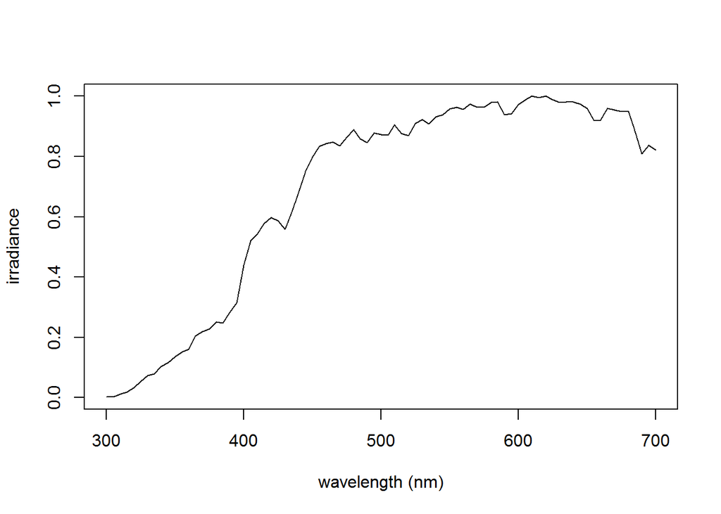

```r
#note that this data frame contains 3 common irradiance spectra: d65, forest shade and woodland shade.
#We will use d65 (also called standard daylight) in the computations below)

plot(Irr5nm$d65~Irr5nm$wl, ylab="irradiance", xlab="wavelength (nm)", type="l")
```

To set the irradiance spectrum in the function “tetra” (or “tri” or “di”, see below), one has to specify the data frame where the irradiance spectra are stored (Irr=Irr5nm) and which column to choose from (irrIrr=2; note that the first column is taken by the wavelengths here).

We used cone sensitivity functions of blue tits (Bennett et al. 2000) computed with the package “pavo” (Maia et al. 2013) which implements formulas from Govardovskii et al. (2000). For details on these computations see the documentation of “pavo”.

**Cone sensitivity functions:**

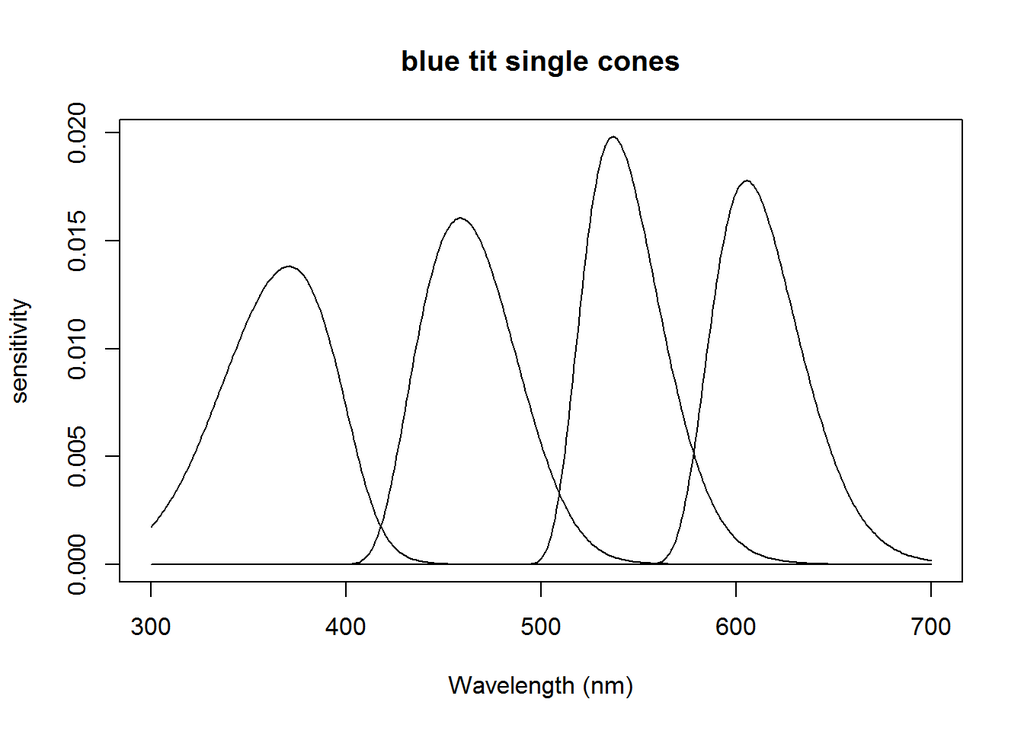

```r
require(pavo)

#sensitivity functions of the four single cones used in colour vision
blue.tit.sens <- sensmodel(c(371,448,502,563),beta=F,lambdacut=c(330,413,507,572), oiltype = c("T", "C", "Y","R"),om= TRUE)

plot(blue.tit.sens, ylab="sensitivity", main="blue tit single cones")
```

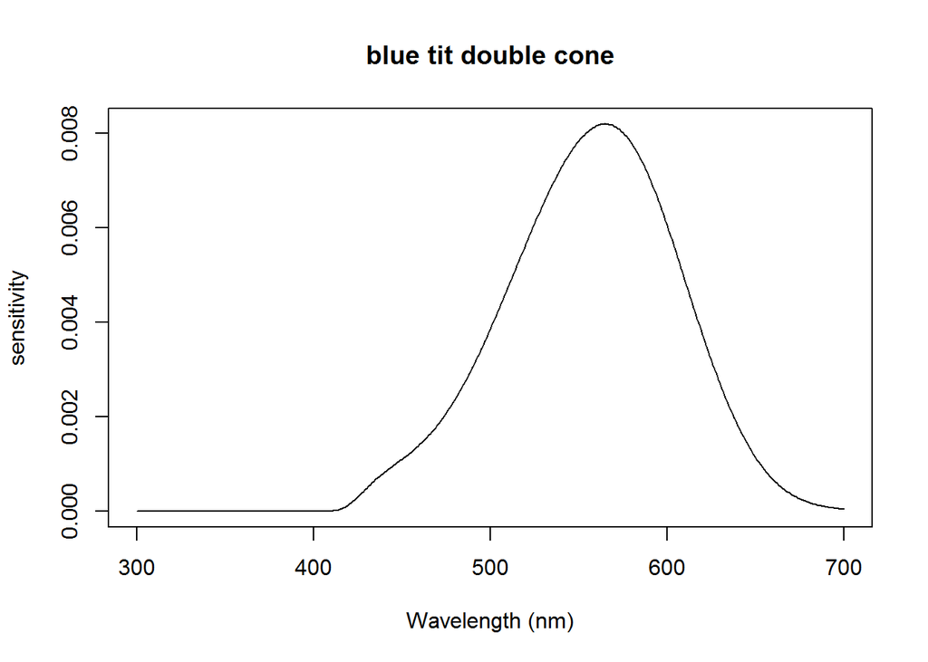

```r
#sensitvity functions for the double cone used for achromatic tasks
bt.double.cone<-sensmodel(c(565), beta=T, oiltype = c("P"),lambdacut=417,  om= TRUE)

plot(bt.double.cone, ylab="sensitivity", main="blue tit double cone")
```

Single cones are used for colour vision in birds while double cones are thought to mediate achromatic discrimination. Here we focus on chromatic aspects but provide a brief instructions to quantify achromatic variability below.

We used cone proportions for blue tits (VS:0.374, S:0.709, M:1, L:1;obtained from Hart 2001). Using these cone proportions assumes that the L cone has a Weber fraction of 0.05 (note this can be changed with argument “WLong=”).This means that, following equation 10 in Vorobyev et al. (1998) the Weber fractions for the other cones are: VS:0.081, S:0.059 and M:0.05. If required Weber fractions can be entered directly with the argument “WeberFrac=”.

## 2.2 Running function “tetra”:

```r
#remember running the scripts containing the functions from Appendix 1
blue.tit.xyz<-tetra(spectra.bt, Tetra=blue.tit.sens, pcones=c(0.3743842,0.7093596,1,1), Irr=Irr5nm, irrIrr=2, wlInclude=TRUE, doubleCone=bt.double.cone)

blue.tit.xyz[1:6,1:20] #some lines of output
```

```
       id   obs wlResol        Irr         Tetra     conesProp
1 B2H0101 crown       5 Irr5nm$d65 blue.tit.sens 0.37,0.71,1,1
2 B2H0175 crown       5 Irr5nm$d65 blue.tit.sens 0.37,0.71,1,1
3 B2H0287 crown       5 Irr5nm$d65 blue.tit.sens 0.37,0.71,1,1
4 B2H0205 crown       5 Irr5nm$d65 blue.tit.sens 0.37,0.71,1,1
5 B2H0349 crown       5 Irr5nm$d65 blue.tit.sens 0.37,0.71,1,1
6 B1R5353 crown       5 Irr5nm$d65 blue.tit.sens 0.37,0.71,1,1
                WeberFrac    VS     S     M     L    DC      x        y
1 0.0817,0.0594,0.05,0.05 6.061 17.57 12.42  9.46 12.19 -10.54  0.29934
2 0.0817,0.0594,0.05,0.05 5.262 15.45 11.80 10.06 11.78 -10.66  1.48331
3 0.0817,0.0594,0.05,0.05 8.765 25.86 18.34 13.57 17.88 -10.71  0.43954
4 0.0817,0.0594,0.05,0.05 7.491 20.99 15.31 12.36 15.14 -10.20  0.58272
5 0.0817,0.0594,0.05,0.05 8.815 24.85 17.35 13.55 17.18 -10.26 -0.01739
6 0.0817,0.0594,0.05,0.05 7.116 20.00 13.95 10.84 13.75 -10.23 -0.04938
       z wl300 wl305 wl310 wl315 wl320
1 -4.300 11.62 13.28 17.96 20.05 23.03
2 -1.743 13.25 15.26 19.47 19.81 22.68
3 -4.692 17.78 21.75 25.88 29.96 33.73
4 -3.176 19.65 22.35 25.12 27.67 31.36
5 -4.077 21.24 24.89 28.64 32.87 35.80
6 -4.170 16.63 20.07 22.95 26.00 29.57
```

The output includes columns documenting the visual parameters used (irradiance, visual sensitivities, cone proportions, Weber fractions), cone quantum catches (VS:S:M:L & double cones), xyz coordinates and the reflectance spectra (between 300 and 700 nm).The latter are included if “wlInclude=TRUE”, which is useful when interpreting PCs based on spectral shape variation (see below).

In order to plot visual coordinates in visual space we split the data into four subsets, one per colour patch.

```r
bt.crown<-subset(blue.tit.xyz, obs=="crown")
bt.cheek<-subset(blue.tit.xyz, obs=="cheek")
bt.breast<-subset(blue.tit.xyz, obs=="breast")
bt.back<-subset(blue.tit.xyz, obs=="back")
```

## 2.3 Plotting in 3D visual space using package “rgl”

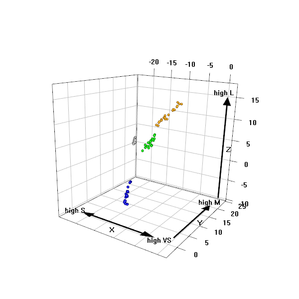

```r
require(rgl)

#setting the limits for the xyz axes.
#Note that in order to keep uniform scaling of axes the range should be the same for each axis
max.range<-max(max(blue.tit.xyz$x)-min(blue.tit.xyz$x),max(blue.tit.xyz$y)-min(blue.tit.xyz$y),max(blue.tit.xyz$z)-min(blue.tit.xyz$z))+5
lim.x<-c(mean(blue.tit.xyz$x)-max.range/2,mean(blue.tit.xyz$x)+max.range/2)
lim.y<-c(mean(blue.tit.xyz$y)-max.range/2, mean(blue.tit.xyz$y)+max.range/2)
lim.z<-c(mean(blue.tit.xyz$z)-max.range/2, mean(blue.tit.xyz$z)+max.range/2)

#a scaffold to put axes on similar scales
plot3d(x=lim.x, y=lim.y, z=lim.z, type="n", aspect=TRUE, box=FALSE, xlab="", ylab="", zlab="")

plot3d(x=bt.crown$x, y=bt.crown$y, z=bt.crown$z, type="s", radius=0.3, add=TRUE, col="blue",box=FALSE)

plot3d(x=bt.cheek$x, y=bt.cheek$y, z=bt.cheek$z, type="s", radius=0.3, add=TRUE, col="grey",box=FALSE)

plot3d(x=bt.breast$x, y=bt.breast$y, z=bt.breast$z, type="s", radius=0.3, add=TRUE, col="orange",box=FALSE)

plot3d(x=bt.back$x, y=bt.back$y, z=bt.back$z, type="s", radius=0.3, add=TRUE, col="green",box=FALSE)

#adding extra info to the graph
#X axis and arrowheads
segments3d(x=c(-20,-5), y=c(0,0), z=c(-10,-10), add=TRUE, lwd=3, add=TRUE)
triangles3d(x=c(-6,-6,-3), y=c(-1,1,0), z=c(-10,-10,-10), add=TRUE)
triangles3d(x=c(-19,-19,-22), y=c(-1,1,0), z=c(-10,-10,-10), add=TRUE)
texts3d(x=-2, y=0, z=-10, texts="high VS")
texts3d(x=-24, y=0, z=-10, texts="high S")
#X axis label
texts3d(x=-12, y=-2, z=-10, texts="X", font=1, cex=1.5)

#Y axis and arrowhead
segments3d(x=c(0,0), y=c(2,18), z=c(-10,-10), add=TRUE, lwd=3, add=TRUE)
triangles3d(x=c(1,-1,0), y=c(17,17,20), z=c(-10,-10,-10), add=TRUE)
text3d(x=-1, y=22, z=-10, texts="high M")
#Y axis label
texts3d(x=1.5, y=11, z=-10, texts="Y", font=1, cex=1.5)

#Z axis and arrowhead
segments3d(x=c(0,0), y=c(25,25), z=c(-10,14), add=TRUE, lwd=3, add=TRUE)
triangles3d(x=c(-1,0,1), y=c(25,25,25), z=c(13,15,13), add=TRUE)
text3d(x=-1, y=25, z=16, texts="high L")
texts3d(x=1.5, y=25, z=3, texts="Z", cex=1.5)

#adds a grid
grid3d(c("x","y+","z"))
```

## 2.4 XYZ visual coordinates are correlated.

Crown:

```r
cor(bt.crown[, c("x", "y", "z")])
```

```
        x       y      z
x  1.0000 -0.7882 -0.400
y -0.7882  1.0000  0.853
z -0.4000  0.8530  1.000
```

Cheek:

```r
cor(bt.cheek[, c("x", "y", "z")])
```

```
        x       y       z
x  1.0000 -0.7939 -0.6456
y -0.7939  1.0000  0.9128
z -0.6456  0.9128  1.0000
```

Breast:

```r
cor(bt.breast[, c("x", "y", "z")])
```

```
       x      y     z
x 1.0000 0.9202 0.906
y 0.9202 1.0000 0.996
z 0.9060 0.9960 1.000
```

Back:

```r
cor(bt.back[, c("x", "y", "z")])
```

```
       x      y      z
x 1.0000 0.6095 0.4149
y 0.6095 1.0000 0.9094
z 0.4149 0.9094 1.0000
```

## 2.5 Principal Component Analyses (PCA) can be used to summarize chromatic variation in visual space.

**Crown:**

```r
PCs<-princomp(~x+y+z, cor=FALSE, data=bt.crown) #note cor=FALSE, to use a covariance matrix
unclass(loadings(PCs))  #component loadings
```

```
   Comp.1  Comp.2  Comp.3
x  0.1904  0.6653  0.7219
y -0.6139 -0.4931  0.6164
z -0.7660  0.5606 -0.3145
```

```r
summary(PCs) #component SDs and variances
```

```
Importance of components:
                       Comp.1 Comp.2   Comp.3
Standard deviation     1.4643 0.5282 0.109357
Proportion of Variance 0.8805 0.1146 0.004911
Cumulative Proportion  0.8805 0.9951 1.000000
```

```r
#adding PCs as variables
bt.crown$PC1<-PCs$scores[,1]
bt.crown$PC2<-PCs$scores[,2]
bt.crown$PC3<-PCs$scores[,3]

#range of variation of PCs
max(bt.crown$PC1)-min(bt.crown$PC1)
```

```
[1] 4.957
```

```r
max(bt.crown$PC2)-min(bt.crown$PC2)
```

```
[1] 2.36
```

```r
max(bt.crown$PC3)-min(bt.crown$PC3)
```

```
[1] 0.4195
```

To facilitate plotting PCxyz lines we can compute xyz coordinates for PC1 line

```r
#computing xyz coordinates for PC1
PCload<- as.data.frame(unclass(loadings(PCs)))
#backcalculates XYZ values based on PC1.

bt.crown$xPC1 <- with(bt.crown, PC1*PCload[1,1]+mean(bt.crown$x))

bt.crown$yPC1 <- with(bt.crown, PC1* PCload [2,1]+mean(bt.crown$y))

bt.crown$zPC1 <- with(bt.crown, PC1* PCload [3,1]+mean(bt.crown$z))
```

**Cheek:**

```r
PCs<-princomp(~x+y+z, cor=FALSE, data=bt.cheek) #note cor=FALSE, to use a covariance matrix
unclass(loadings(PCs))  #component loadings
```

```
   Comp.1   Comp.2  Comp.3
x  0.3640  0.82608 -0.4303
y -0.7260 -0.03777 -0.6867
z -0.5835  0.56229  0.5860
```

```r
summary(PCs) #component SDs and variances
```

```
Importance of components:
                       Comp.1  Comp.2  Comp.3
Standard deviation     0.4822 0.14479 0.07596
Proportion of Variance 0.8969 0.08085 0.02225
Cumulative Proportion  0.8969 0.97775 1.00000
```

```r
#adding PCs as variables
bt.cheek$PC1<-PCs$scores[,1]
bt.cheek$PC2<-PCs$scores[,2]
bt.cheek$PC3<-PCs$scores[,3]

#range of variation of PCs
max(bt.cheek$PC1)-min(bt.cheek$PC1)
```

```
[1] 1.81
```

```r
max(bt.cheek$PC2)-min(bt.cheek$PC2)
```

```
[1] 0.5791
```

```r
max(bt.cheek$PC3)-min(bt.cheek$PC3)
```

```
[1] 0.3121
```

To facilitate plotting PCxyz lines we can compute xyz coordinates for PC1 line

```r
#computing xyz coordinates for PC1
PCload<- as.data.frame(unclass(loadings(PCs)))
#backcalculates XYZ values based on PC1.

bt.cheek$xPC1 <- with(bt.cheek, PC1*PCload[1,1]+mean(bt.cheek$x))

bt.cheek$yPC1 <- with(bt.cheek, PC1* PCload [2,1]+mean(bt.cheek$y))

bt.cheek$zPC1 <- with(bt.cheek, PC1* PCload [3,1]+mean(bt.cheek$z))
```

**Breast:**

```r
PCs<-princomp(~x+y+z, cor=FALSE, data=bt.breast) #note cor=FALSE, to use a covariance matrix
unclass(loadings(PCs))  #component loadings
```

```
   Comp.1  Comp.2  Comp.3
x -0.2653  0.9542  0.1380
y -0.8047 -0.1403 -0.5769
z -0.5311 -0.2641  0.8051
```

```r
summary(PCs) #component SDs and variances
```

```
Importance of components:
                       Comp.1 Comp.2   Comp.3
Standard deviation     2.6478 0.2944 0.097392
Proportion of Variance 0.9865 0.0122 0.001335
Cumulative Proportion  0.9865 0.9987 1.000000
```

```r
#adding PCs as variables
bt.breast$PC1<-PCs$scores[,1]
bt.breast$PC2<-PCs$scores[,2]
bt.breast$PC3<-PCs$scores[,3]

#range of variation of PCs
max(bt.breast$PC1)-min(bt.breast$PC1)
```

```
[1] 8.044
```

```r
max(bt.breast$PC2)-min(bt.breast$PC2)
```

```
[1] 1.203
```

```r
max(bt.breast$PC3)-min(bt.breast$PC3)
```

```
[1] 0.3679
```

To facilitate plotting PCxyz lines we can compute xyz coordinates for PC1 line

```r
#computing xyz coordinates for PC1
PCload<- as.data.frame(unclass(loadings(PCs)))
#backcalculates XYZ values based on PC1.

bt.breast$xPC1 <- with(bt.breast, PC1*PCload[1,1]+mean(bt.breast$x))

bt.breast$yPC1 <- with(bt.breast, PC1* PCload [2,1]+mean(bt.breast$y))

bt.breast$zPC1 <- with(bt.breast, PC1* PCload [3,1]+mean(bt.breast$z))
```

**Back:**

```r
PCs<-princomp(~x+y+z, cor=FALSE, data=bt.back) #note cor=FALSE, to use a covariance matrix
unclass(loadings(PCs))  #component loadings
```

```
   Comp.1  Comp.2  Comp.3
x -0.1316  0.6389  0.7580
y -0.7700  0.4157 -0.4840
z -0.6243 -0.6473  0.4373
```

```r
summary(PCs) #component SDs and variances
```

```
Importance of components:
                       Comp.1 Comp.2  Comp.3
Standard deviation     1.2678 0.3180 0.17792
Proportion of Variance 0.9237 0.0581 0.01819
Cumulative Proportion  0.9237 0.9818 1.00000
```

```r
#adding PCs as variables
bt.back$PC1<-PCs$scores[,1]
bt.back$PC2<-PCs$scores[,2]
bt.back$PC3<-PCs$scores[,3]

#range of variation of PCs
max(bt.back$PC1)-min(bt.back$PC1)
```

```
[1] 4.936
```

```r
max(bt.back$PC2)-min(bt.back$PC2)
```

```
[1] 1.205
```

```r
max(bt.back$PC3)-min(bt.back$PC3)
```

```
[1] 0.7095
```

To facilitate plotting PCxyz lines we can compute xyz coordinates for PC1 line

```r
#computing xyz coordinates for PC1
PCload<- as.data.frame(unclass(loadings(PCs)))
#backcalculates XYZ values based on PC1.

bt.back$xPC1 <- with(bt.back, PC1*PCload[1,1]+mean(bt.back$x))

bt.back$yPC1 <- with(bt.back, PC1* PCload [2,1]+mean(bt.back$y))

bt.back$zPC1 <- with(bt.back, PC1* PCload [3,1]+mean(bt.back$z))
```

## 2.6 PC1 lines can be plotted in visual space

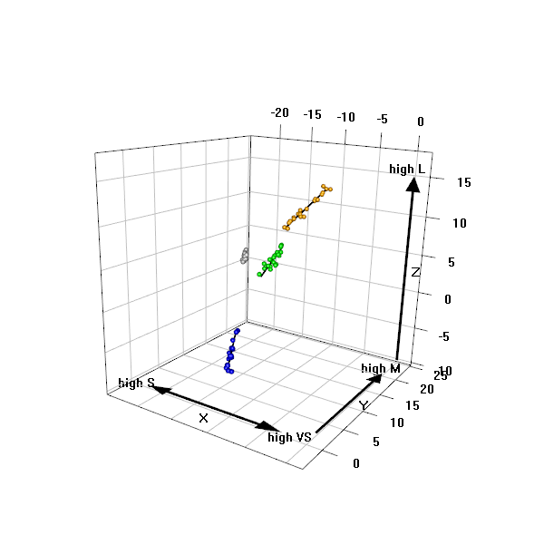

```r
#setting the limits for the xyz axes.
#Note that in order to keep uniform scaling of axes the range should be the same for each axis
max.range<-max(max(blue.tit.xyz$x)-min(blue.tit.xyz$x),max(blue.tit.xyz$y)-min(blue.tit.xyz$y),max(blue.tit.xyz$z)-min(blue.tit.xyz$z))+5
lim.x<-c(mean(blue.tit.xyz$x)-max.range/2,mean(blue.tit.xyz$x)+max.range/2)
lim.y<-c(mean(blue.tit.xyz$y)-max.range/2, mean(blue.tit.xyz$y)+max.range/2)
lim.z<-c(mean(blue.tit.xyz$z)-max.range/2, mean(blue.tit.xyz$z)+max.range/2)

#a scaffold to put axes on similar scales
plot3d(x=lim.x, y=lim.y, z=lim.z, type="n", aspect=TRUE, box=FALSE, xlab="", ylab="", zlab="")

plot3d(x=bt.crown$x, y=bt.crown$y, z=bt.crown$z, type="s", radius=0.3, add=TRUE, col="blue",box=FALSE)

plot3d(x=bt.cheek$x, y=bt.cheek$y, z=bt.cheek$z, type="s", radius=0.3, add=TRUE, col="grey",box=FALSE)

plot3d(x=bt.breast$x, y=bt.breast$y, z=bt.breast$z, type="s", radius=0.3, add=TRUE, col="orange",box=FALSE)

plot3d(x=bt.back$x, y=bt.back$y, z=bt.back$z, type="s", radius=0.3, add=TRUE, col="green",box=FALSE)

#plotting PC1 lines
plot3d(x=bt.crown$xPC1, y=bt.crown$yPC1, z=bt.crown$zPC1, type="l",  add=TRUE, lwd=2, col="black",box=FALSE)

plot3d(x=bt.cheek$xPC1, y=bt.cheek$yPC1, z=bt.cheek$zPC1, type="l",  add=TRUE, lwd=2, col="black",box=FALSE)

plot3d(x=bt.breast$xPC1, y=bt.breast$yPC1, z=bt.breast$zPC1, type="l",  add=TRUE, lwd=2, col="black",box=FALSE)

plot3d(x=bt.back$xPC1, y=bt.back$yPC1, z=bt.back$zPC1, type="l",  add=TRUE, lwd=2, col="black",box=FALSE)

#adding extra info to the graph
#X axis and arrowheads
segments3d(x=c(-20,-5), y=c(0,0), z=c(-10,-10), add=TRUE, lwd=3, add=TRUE)
triangles3d(x=c(-6,-6,-3), y=c(-1,1,0), z=c(-10,-10,-10), add=TRUE)
triangles3d(x=c(-19,-19,-22), y=c(-1,1,0), z=c(-10,-10,-10), add=TRUE)
texts3d(x=-2, y=0, z=-10, texts="high VS")
texts3d(x=-24, y=0, z=-10, texts="high S")
#X axis label
texts3d(x=-12, y=-2, z=-10, texts="X", font=1, cex=1.5)

#Y axis and arrowhead
segments3d(x=c(0,0), y=c(2,18), z=c(-10,-10), add=TRUE, lwd=3, add=TRUE)
triangles3d(x=c(1,-1,0), y=c(17,17,20), z=c(-10,-10,-10), add=TRUE)
text3d(x=-1, y=22, z=-10, texts="high M")
#Y axis label
texts3d(x=1.5, y=11, z=-10, texts="Y", font=1, cex=1.5)

#Z axis and arrowhead
segments3d(x=c(0,0), y=c(25,25), z=c(-10,14), add=TRUE, lwd=3, add=TRUE)
triangles3d(x=c(-1,0,1), y=c(25,25,25), z=c(13,15,13), add=TRUE)
text3d(x=-1, y=25, z=16, texts="high L")
texts3d(x=1.5, y=25, z=3, texts="Z", cex=1.5)

#adds a grid
grid3d(c("x","y+","z"))
```

## 2.7 Linking PC1 to variation in spectra shape

**Crown:**

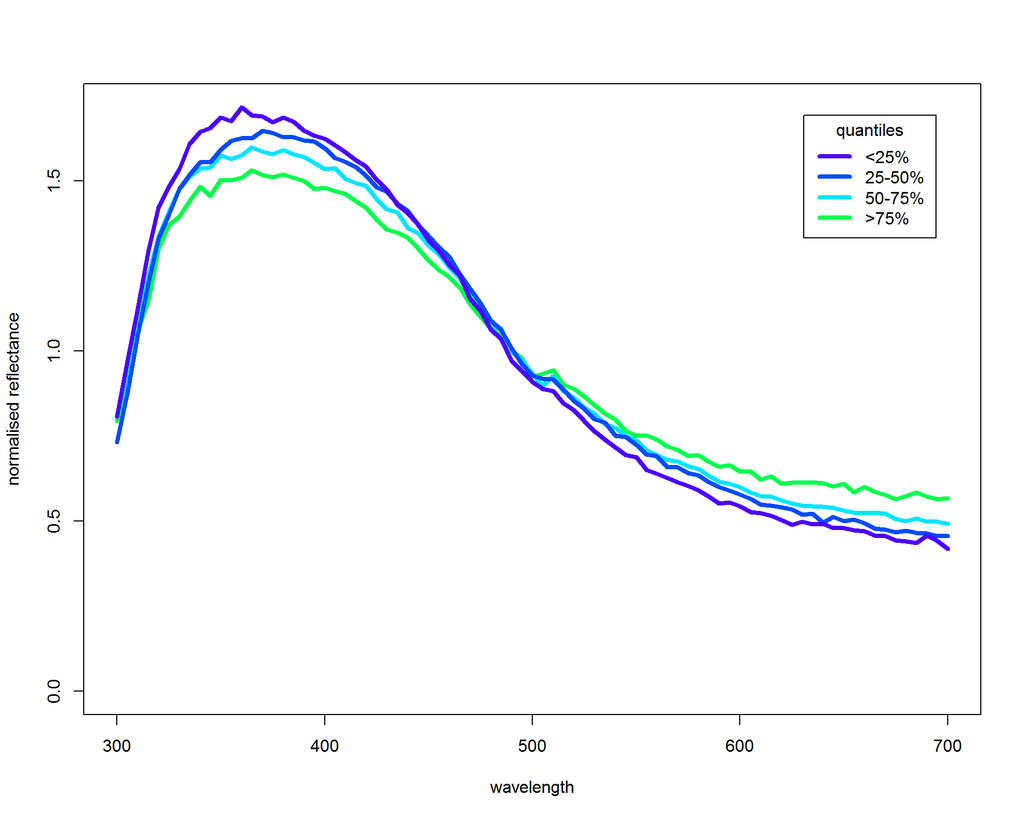

```r
#assigns the dataset to be used
Data<-bt.crown
#computes quantiles on PC1 and PC2
Data$PC1q <-factor(1+(Data$PC1>quantile(Data$PC1, probs=0.25) & Data$PC1<=quantile(Data$PC1, probs=0.5))+2*(Data$PC1>quantile(Data$PC1, probs=0.5) & Data$PC1<=quantile(Data$PC1, probs=0.75))+3*(Data$PC1>quantile(Data$PC1, probs=0.75) & Data$PC1<=max(Data$PC1)))
Data$PC2q <-factor(1+(Data$PC2>quantile(Data$PC2, probs=0.25) & Data$PC2<=quantile(Data$PC2, probs=0.5))+2*(Data$PC2>quantile(Data$PC2, probs=0.5) & Data$PC2<=quantile(Data$PC2, probs=0.75))+3*(Data$PC2>quantile(Data$PC2, probs=0.75) & Data$PC2<=max(Data$PC2)))

bt.crown$PC1q<-Data$PC1q

#average spectra of the 4 quantiles belonging to PC1
spectra<-(aggregate(bt.crown[,16:96], by=list(q=Data$PC1q), mean)[,-1])

spectra<-na.omit(as.data.frame(t(spectra)))

wavelength<-seq(300,700,along=spectra$V1)


#finds the max reflectance to adjust ylim automatically
ymax<-max(I(spectra$V1/mean(spectra$V1)), I(spectra$V2/mean(spectra$V2)), I(spectra$V3/mean(spectra$V3)), I(spectra$V4/mean(spectra$V4)))

#colours palette
col.pal<-topo.colors(n=5)

plot(I(spectra$V1/mean(spectra$V1))~wavelength, ylim=c(0, ymax), xlab="wavelength", ylab="normalised reflectance", pch=0, col="white")
par(fig=c(0,1,0,1), new=TRUE)
lines(loess(I(spectra$V1/mean(spectra$V1))~wavelength, span=1), ylim=c(0, ymax), xlab="wavelength", ylab="normalised reflectance", lwd=4, col=col.pal[4])
par(fig=c(0,1,0,1), new=TRUE)
lines(loess(I(spectra$V2/mean(spectra$V2))~wavelength, span=0.99), ylim=c(0, ymax), ylab="normalised reflectance", lwd=4, col=col.pal[3])
par(fig=c(0,1,0,1), new=TRUE)
lines(loess(I(spectra$V3/mean(spectra$V3))~wavelength, span=0.99), ylim=c(0, ymax), ylab="reflectance", lwd=4, col=col.pal[2])
par(fig=c(0,1,0,1), new=TRUE)
lines(loess(I(spectra$V4/mean(spectra$V4))~wavelength, span=0.99), ylim=c(0, ymax), ylab="reflectance", lwd=4, col=col.pal[1])
legend("topright", inset=0.05, title="quantiles", c("<25%", "25-50%", "50-75%", ">75%"), lwd=c(4, 4, 4, 4), col=c(col.pal))
```

Now, we can plot points in visual space using different colours for each quantile of PC1 which correspond to the average reflectance spectra depicted above.

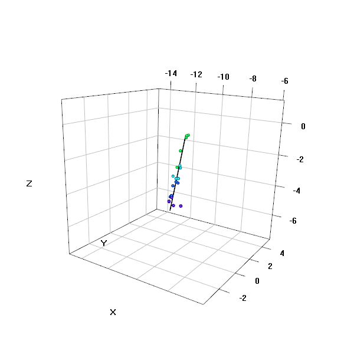

```r
#setting the limits for the xyz axes.
#Note that in order to keep uniform scaling of axes the range should be the same for each axis
max.range<-max(max(bt.crown$x)-min(bt.crown$x),max(bt.crown$y)-min(bt.crown$y),max(bt.crown$z)-min(bt.crown$z))+5
lim.x<-c(mean(bt.crown$x)-max.range/2,mean(bt.crown$x)+max.range/2)
lim.y<-c(mean(bt.crown$y)-max.range/2, mean(bt.crown$y)+max.range/2)
lim.z<-c(mean(bt.crown$z)-max.range/2, mean(bt.crown$z)+max.range/2)


#a scaffold to put axes on similar scales
plot3d(x=lim.x, y=lim.y, z=lim.z, type="n", aspect=TRUE, box=FALSE, xlab="X", ylab="Y", zlab="Z")


plot3d(x=bt.crown$x[bt.crown$PC1q==1], y=bt.crown$y[bt.crown$PC1q==1], z=bt.crown$z[bt.crown$PC1q==1], type="s", radius=0.1, add=TRUE, col=col.pal[4])
plot3d(x=bt.crown$x[bt.crown$PC1q==2], y=bt.crown$y[bt.crown$PC1q==2], z=bt.crown$z[bt.crown$PC1q==2], type="s", radius=0.1, add=TRUE, col=col.pal[3])
plot3d(x=bt.crown$x[bt.crown$PC1q==3], y=bt.crown$y[bt.crown$PC1q==3], z=bt.crown$z[bt.crown$PC1q==3], type="s", radius=0.1, add=TRUE, col=col.pal[2])
plot3d(x=bt.crown$x[bt.crown$PC1q==4], y=bt.crown$y[bt.crown$PC1q==4], z=bt.crown$z[bt.crown$PC1q==4], type="s", radius=0.1, add=TRUE, col=col.pal[1])

#plots the PC1
plot3d(x=bt.crown$xPC1, y=bt.crown$yPC1, z=bt.crown$zPC1, type="l", lwd=2, add=TRUE, col="black")

#adds a grid
grid3d(c("x","y+","z"))
```

**Cheek:**

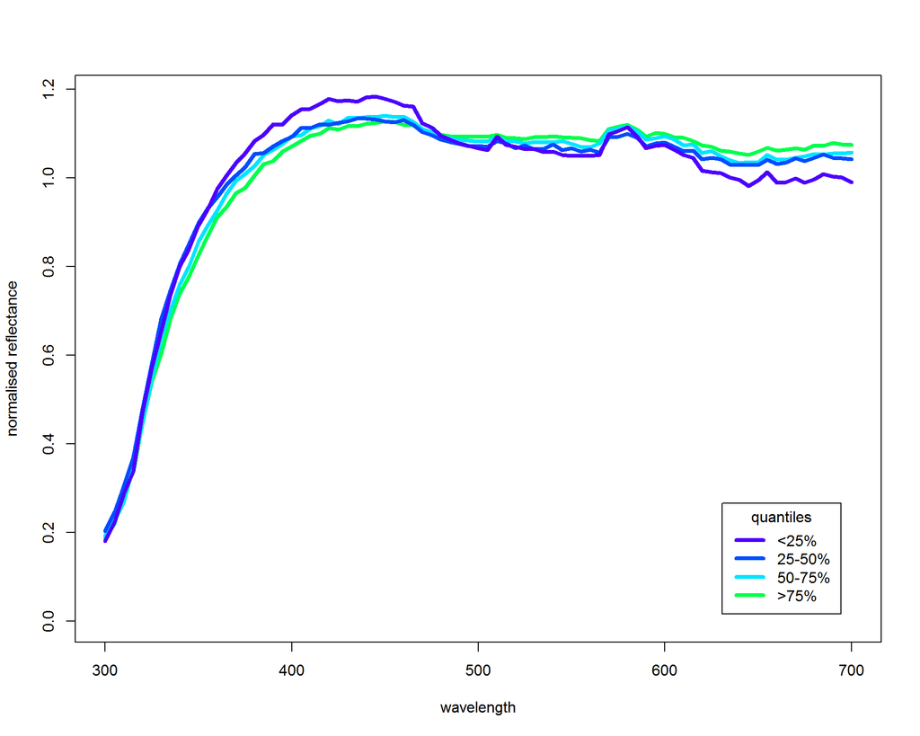

```r
#assigns the dataset to be used
Data<-bt.cheek
#computes quantiles on PC1 and PC2
Data$PC1q <-factor(1+(Data$PC1>quantile(Data$PC1, probs=0.25) & Data$PC1<=quantile(Data$PC1, probs=0.5))+2*(Data$PC1>quantile(Data$PC1, probs=0.5) & Data$PC1<=quantile(Data$PC1, probs=0.75))+3*(Data$PC1>quantile(Data$PC1, probs=0.75) & Data$PC1<=max(Data$PC1)))
Data$PC2q <-factor(1+(Data$PC2>quantile(Data$PC2, probs=0.25) & Data$PC2<=quantile(Data$PC2, probs=0.5))+2*(Data$PC2>quantile(Data$PC2, probs=0.5) & Data$PC2<=quantile(Data$PC2, probs=0.75))+3*(Data$PC2>quantile(Data$PC2, probs=0.75) & Data$PC2<=max(Data$PC2)))

bt.cheek$PC1q<-Data$PC1q

#average spectra of the 4 quantiles belonging to PC1
spectra<-(aggregate(bt.cheek[,16:96], by=list(q=Data$PC1q), mean)[,-1])

spectra<-na.omit(as.data.frame(t(spectra)))

wavelength<-seq(300,700,along=spectra$V1)


#finds the max reflectance to adjust ylim automatically
ymax<-max(I(spectra$V1/mean(spectra$V1)), I(spectra$V2/mean(spectra$V2)), I(spectra$V3/mean(spectra$V3)), I(spectra$V4/mean(spectra$V4)))

#colours palette
col.pal<-topo.colors(n=5)

plot(I(spectra$V1/mean(spectra$V1))~wavelength, ylim=c(0, ymax), xlab="wavelength", ylab="normalised reflectance", pch=0, col="white")
par(fig=c(0,1,0,1), new=TRUE)
lines(loess(I(spectra$V1/mean(spectra$V1))~wavelength, span=1), ylim=c(0, ymax), xlab="wavelength", ylab="normalised reflectance", lwd=4, col=col.pal[4])
par(fig=c(0,1,0,1), new=TRUE)
lines(loess(I(spectra$V2/mean(spectra$V2))~wavelength, span=0.99), ylim=c(0, ymax), ylab="normalised reflectance", lwd=4, col=col.pal[3])
par(fig=c(0,1,0,1), new=TRUE)
lines(loess(I(spectra$V3/mean(spectra$V3))~wavelength, span=0.99), ylim=c(0, ymax), ylab="reflectance", lwd=4, col=col.pal[2])
par(fig=c(0,1,0,1), new=TRUE)
lines(loess(I(spectra$V4/mean(spectra$V4))~wavelength, span=0.99), ylim=c(0, ymax), ylab="reflectance", lwd=4, col=col.pal[1])
legend("bottomright", inset=0.05, title="quantiles", c("<25%", "25-50%", "50-75%", ">75%"), lwd=c(4, 4, 4, 4), col=c(col.pal))
```

Now, we can plot points in visual space using different colours for each quantile of PC1 which correspond to the average reflectance spectra depicted above.

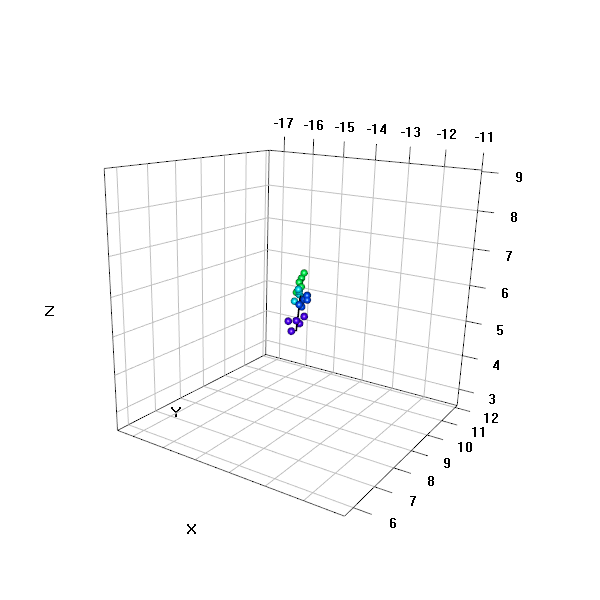

```r
#setting the limits for the xyz axes.
#Note that in order to keep uniform scaling of axes the range should be the same for each axis
max.range<-max(max(bt.cheek$x)-min(bt.cheek$x),max(bt.cheek$y)-min(bt.cheek$y),max(bt.cheek$z)-min(bt.cheek$z))+5
lim.x<-c(mean(bt.cheek$x)-max.range/2,mean(bt.cheek$x)+max.range/2)
lim.y<-c(mean(bt.cheek$y)-max.range/2, mean(bt.cheek$y)+max.range/2)
lim.z<-c(mean(bt.cheek$z)-max.range/2, mean(bt.cheek$z)+max.range/2)


#a scaffold to put axes on similar scales
plot3d(x=lim.x, y=lim.y, z=lim.z, type="n", aspect=TRUE, box=FALSE, xlab="X", ylab="Y", zlab="Z")


plot3d(x=bt.cheek$x[bt.cheek$PC1q==1], y=bt.cheek$y[bt.cheek$PC1q==1], z=bt.cheek$z[bt.cheek$PC1q==1], type="s", radius=0.1, add=TRUE, col=col.pal[4])
plot3d(x=bt.cheek$x[bt.cheek$PC1q==2], y=bt.cheek$y[bt.cheek$PC1q==2], z=bt.cheek$z[bt.cheek$PC1q==2], type="s", radius=0.1, add=TRUE, col=col.pal[3])
plot3d(x=bt.cheek$x[bt.cheek$PC1q==3], y=bt.cheek$y[bt.cheek$PC1q==3], z=bt.cheek$z[bt.cheek$PC1q==3], type="s", radius=0.1, add=TRUE, col=col.pal[2])
plot3d(x=bt.cheek$x[bt.cheek$PC1q==4], y=bt.cheek$y[bt.cheek$PC1q==4], z=bt.cheek$z[bt.cheek$PC1q==4], type="s", radius=0.1, add=TRUE, col=col.pal[1])

#plots the PC1
plot3d(x=bt.cheek$xPC1, y=bt.cheek$yPC1, z=bt.cheek$zPC1, type="l", lwd=2, add=TRUE, col="black")

#adds a grid
grid3d(c("x","y+","z"))
```

**Breast:**

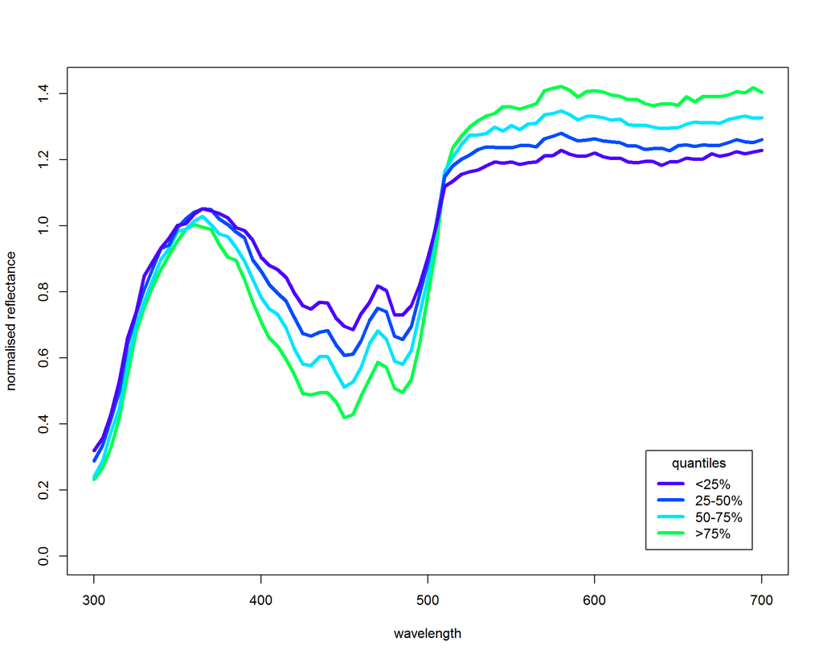

```r
#assigns the dataset to be used
Data<-bt.breast
#computes quantiles on PC1 and PC2
Data$PC1q <-factor(1+(Data$PC1>quantile(Data$PC1, probs=0.25) & Data$PC1<=quantile(Data$PC1, probs=0.5))+2*(Data$PC1>quantile(Data$PC1, probs=0.5) & Data$PC1<=quantile(Data$PC1, probs=0.75))+3*(Data$PC1>quantile(Data$PC1, probs=0.75) & Data$PC1<=max(Data$PC1)))
Data$PC2q <-factor(1+(Data$PC2>quantile(Data$PC2, probs=0.25) & Data$PC2<=quantile(Data$PC2, probs=0.5))+2*(Data$PC2>quantile(Data$PC2, probs=0.5) & Data$PC2<=quantile(Data$PC2, probs=0.75))+3*(Data$PC2>quantile(Data$PC2, probs=0.75) & Data$PC2<=max(Data$PC2)))

bt.breast$PC1q<-Data$PC1q

#average spectra of the 4 quantiles belonging to PC1
spectra<-(aggregate(bt.breast[,16:96], by=list(q=Data$PC1q), mean)[,-1])

spectra<-na.omit(as.data.frame(t(spectra)))

wavelength<-seq(300,700,along=spectra$V1)


#finds the max reflectance to adjust ylim automatically
ymax<-max(I(spectra$V1/mean(spectra$V1)), I(spectra$V2/mean(spectra$V2)), I(spectra$V3/mean(spectra$V3)), I(spectra$V4/mean(spectra$V4)))

#colours palette
col.pal<-topo.colors(n=5)

plot(I(spectra$V1/mean(spectra$V1))~wavelength, ylim=c(0, ymax), xlab="wavelength", ylab="normalised reflectance", pch=0, col="white")
par(fig=c(0,1,0,1), new=TRUE)
lines(loess(I(spectra$V1/mean(spectra$V1))~wavelength, span=1), ylim=c(0, ymax), xlab="wavelength", ylab="normalised reflectance", lwd=4, col=col.pal[4])
par(fig=c(0,1,0,1), new=TRUE)
lines(loess(I(spectra$V2/mean(spectra$V2))~wavelength, span=0.99), ylim=c(0, ymax), ylab="normalised reflectance", lwd=4, col=col.pal[3])
par(fig=c(0,1,0,1), new=TRUE)
lines(loess(I(spectra$V3/mean(spectra$V3))~wavelength, span=0.99), ylim=c(0, ymax), ylab="reflectance", lwd=4, col=col.pal[2])
par(fig=c(0,1,0,1), new=TRUE)
lines(loess(I(spectra$V4/mean(spectra$V4))~wavelength, span=0.99), ylim=c(0, ymax), ylab="reflectance", lwd=4, col=col.pal[1])
legend("bottomright", inset=0.05, title="quantiles", c("<25%", "25-50%", "50-75%", ">75%"), lwd=c(4, 4, 4, 4), col=c(col.pal))
```

Now, we can plot points in visual space using different colours for each quantile of PC1 which correspond to the average reflectance spectra depicted above.

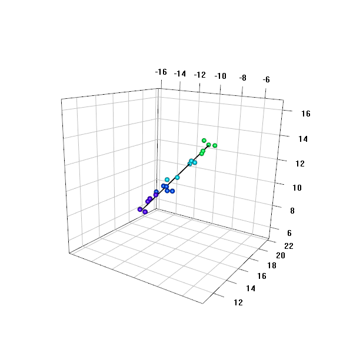

```r
#setting the limits for the xyz axes.
#Note that in order to keep uniform scaling of axes the range should be the same for each axis
max.range<-max(max(bt.breast$x)-min(bt.breast$x),max(bt.breast$y)-min(bt.breast$y),max(bt.breast$z)-min(bt.breast$z))+5
lim.x<-c(mean(bt.breast$x)-max.range/2,mean(bt.breast$x)+max.range/2)
lim.y<-c(mean(bt.breast$y)-max.range/2, mean(bt.breast$y)+max.range/2)
lim.z<-c(mean(bt.breast$z)-max.range/2, mean(bt.breast$z)+max.range/2)


#a scaffold to put axes on similar scales
plot3d(x=lim.x, y=lim.y, z=lim.z, type="n", aspect=TRUE, box=FALSE, xlab="", ylab="", zlab="")


plot3d(x=bt.breast$x[bt.breast$PC1q==1], y=bt.breast$y[bt.breast$PC1q==1], z=bt.breast$z[bt.breast$PC1q==1], type="s", radius=0.2, add=TRUE, col=col.pal[4])
plot3d(x=bt.breast$x[bt.breast$PC1q==2], y=bt.breast$y[bt.breast$PC1q==2], z=bt.breast$z[bt.breast$PC1q==2], type="s", radius=0.2, add=TRUE, col=col.pal[3])
plot3d(x=bt.breast$x[bt.breast$PC1q==3], y=bt.breast$y[bt.breast$PC1q==3], z=bt.breast$z[bt.breast$PC1q==3], type="s", radius=0.2, add=TRUE, col=col.pal[2])
plot3d(x=bt.breast$x[bt.breast$PC1q==4], y=bt.breast$y[bt.breast$PC1q==4], z=bt.breast$z[bt.breast$PC1q==4], type="s", radius=0.2, add=TRUE, col=col.pal[1])

#plots the PC1
plot3d(x=bt.breast$xPC1, y=bt.breast$yPC1, z=bt.breast$zPC1, type="l", lwd=2, add=TRUE, col="black")

#adds a grid
grid3d(c("x","y+","z"))
```

**Back:**

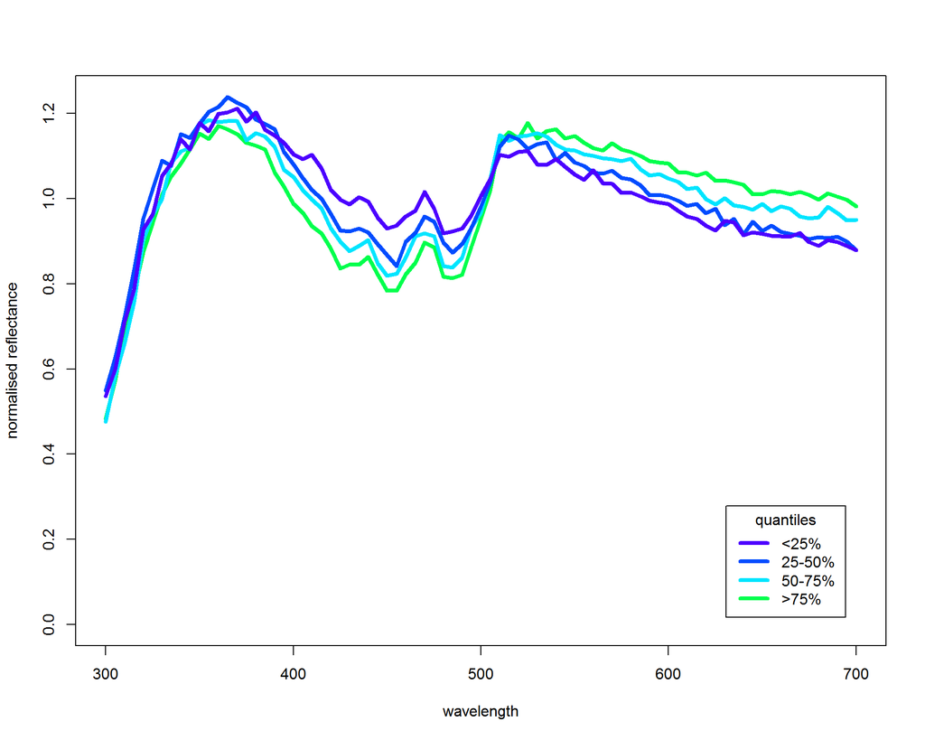

```r
#assigns the dataset to be used
Data<-bt.back
#computes quantiles on PC1 and PC2
Data$PC1q <-factor(1+(Data$PC1>quantile(Data$PC1, probs=0.25) & Data$PC1<=quantile(Data$PC1, probs=0.5))+2*(Data$PC1>quantile(Data$PC1, probs=0.5) & Data$PC1<=quantile(Data$PC1, probs=0.75))+3*(Data$PC1>quantile(Data$PC1, probs=0.75) & Data$PC1<=max(Data$PC1)))
Data$PC2q <-factor(1+(Data$PC2>quantile(Data$PC2, probs=0.25) & Data$PC2<=quantile(Data$PC2, probs=0.5))+2*(Data$PC2>quantile(Data$PC2, probs=0.5) & Data$PC2<=quantile(Data$PC2, probs=0.75))+3*(Data$PC2>quantile(Data$PC2, probs=0.75) & Data$PC2<=max(Data$PC2)))

bt.back$PC1q<-Data$PC1q

#average spectra of the 4 quantiles belonging to PC1
spectra<-(aggregate(bt.back[,16:96], by=list(q=Data$PC1q), mean)[,-1])

spectra<-na.omit(as.data.frame(t(spectra)))

wavelength<-seq(300,700,along=spectra$V1)


#finds the max reflectance to adjust ylim automatically
ymax<-max(I(spectra$V1/mean(spectra$V1)), I(spectra$V2/mean(spectra$V2)), I(spectra$V3/mean(spectra$V3)), I(spectra$V4/mean(spectra$V4)))

#colours palette
col.pal<-topo.colors(n=5)

plot(I(spectra$V1/mean(spectra$V1))~wavelength, ylim=c(0, ymax), xlab="wavelength", ylab="normalised reflectance", pch=0, col="white")
par(fig=c(0,1,0,1), new=TRUE)
lines(loess(I(spectra$V1/mean(spectra$V1))~wavelength, span=1), ylim=c(0, ymax), xlab="wavelength", ylab="normalised reflectance", lwd=4, col=col.pal[4])
par(fig=c(0,1,0,1), new=TRUE)
lines(loess(I(spectra$V2/mean(spectra$V2))~wavelength, span=0.99), ylim=c(0, ymax), ylab="normalised reflectance", lwd=4, col=col.pal[3])
par(fig=c(0,1,0,1), new=TRUE)
lines(loess(I(spectra$V3/mean(spectra$V3))~wavelength, span=0.99), ylim=c(0, ymax), ylab="reflectance", lwd=4, col=col.pal[2])
par(fig=c(0,1,0,1), new=TRUE)
lines(loess(I(spectra$V4/mean(spectra$V4))~wavelength, span=0.99), ylim=c(0, ymax), ylab="reflectance", lwd=4, col=col.pal[1])
legend("bottomright", inset=0.05, title="quantiles", c("<25%", "25-50%", "50-75%", ">75%"), lwd=c(4, 4, 4, 4), col=c(col.pal))
```

Now, we can plot points in visual space using different colours for each quantile of PC1 which correspond to the average reflectance spectra depicted above.

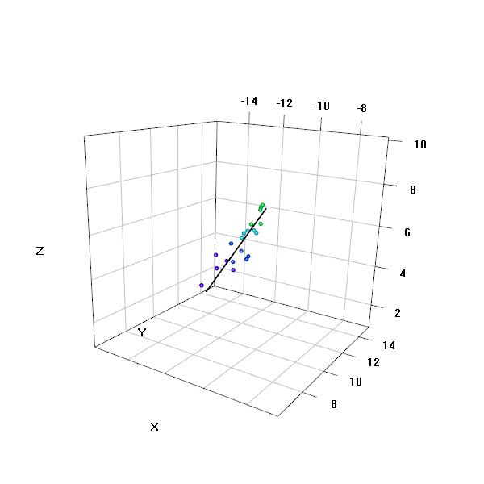

```r
#setting the limits for the xyz axes.
#Note that in order to keep uniform scaling of axes the range should be the same for each axis
max.range<-max(max(bt.back$x)-min(bt.back$x),max(bt.back$y)-min(bt.back$y),max(bt.back$z)-min(bt.back$z))+5
lim.x<-c(mean(bt.back$x)-max.range/2,mean(bt.back$x)+max.range/2)
lim.y<-c(mean(bt.back$y)-max.range/2, mean(bt.back$y)+max.range/2)
lim.z<-c(mean(bt.back$z)-max.range/2, mean(bt.back$z)+max.range/2)


#a scaffold to put axes on similar scales
plot3d(x=lim.x, y=lim.y, z=lim.z, type="n", aspect=TRUE, box=FALSE, xlab="X", ylab="Y", zlab="Z")


plot3d(x=bt.back$x[bt.back$PC1q==1], y=bt.back$y[bt.back$PC1q==1], z=bt.back$z[bt.back$PC1q==1], type="s", radius=0.1, add=TRUE, col=col.pal[4])
plot3d(x=bt.back$x[bt.back$PC1q==2], y=bt.back$y[bt.back$PC1q==2], z=bt.back$z[bt.back$PC1q==2], type="s", radius=0.1, add=TRUE, col=col.pal[3])
plot3d(x=bt.back$x[bt.back$PC1q==3], y=bt.back$y[bt.back$PC1q==3], z=bt.back$z[bt.back$PC1q==3], type="s", radius=0.1, add=TRUE, col=col.pal[2])
plot3d(x=bt.back$x[bt.back$PC1q==4], y=bt.back$y[bt.back$PC1q==4], z=bt.back$z[bt.back$PC1q==4], type="s", radius=0.1, add=TRUE, col=col.pal[1])

#plots the PC1
plot3d(x=bt.back$xPC1, y=bt.back$yPC1, z=bt.back$zPC1, type="l", lwd=2, add=TRUE, col="black")

#adds a grid
grid3d(c("x","y+","z"))
```

## 2.8 Achromatic variability

Sensitivity to achromatic cues is apparently mediated by double cones by which have the same pigment as L cones in birds but have a yellowish-green oil droplet instead of the the red one found in L cones and thus have a wider sensitivity range.Double cone quantum catches are computed by function tetra and can be used to compute achromatic contrast.

This is usually done following Siddiqi et al.(2004) assuming the same Weber fraction as the L cone due to the fact that they have the same pigment. Values of achromatic contrast are thus measured in JNDs as well. By computing achromatic contrast between each reflectance spectrum and a reference spectrum we can obtain a scale of achromatic brightness measured in JNDs. As a reference we use a very low value of double cone quantum catch (close to zero, e.g. 0.001) which would correspond to a very dark spectrum. Higher values thus correspond to spectra with higher absolute reflectance in the sensitvity range of the double cone.

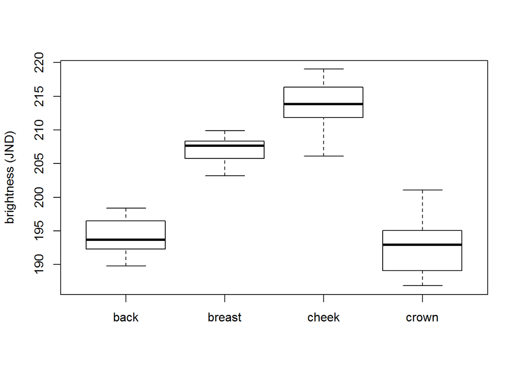

```r
#computing achromatic contrast
blue.tit.xyz$DL<-(log(blue.tit.xyz$DC)-log(0.001))/0.05

boxplot(DL~obs, data=blue.tit.xyz, ylab="brightness (JND)")
```

## 2.9 Functions tri and di

These functions compute chromatic coordinates for tri- (xy) and di-chromatic (x) visual systems. As with tetra you have to run the corresponding scripts from Appendix 1 before you can run the functions below.

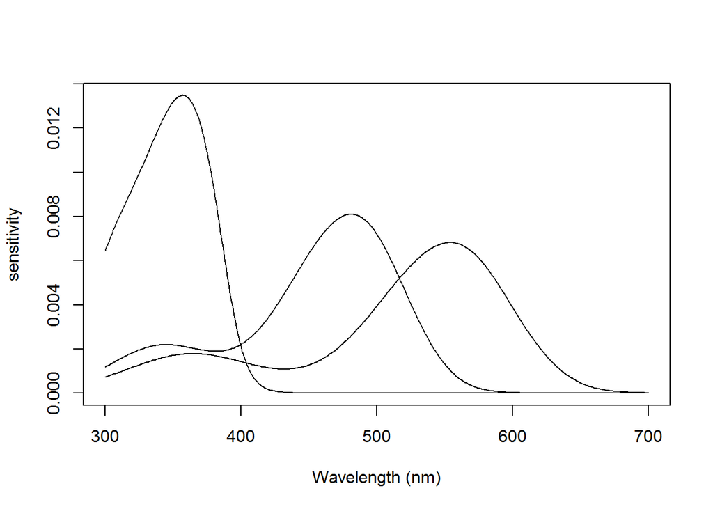

```r
require(pavo)
snake.sense <- sensmodel(c(358.4,481.2,554),beta=TRUE, oiltype = c("T", "C","R"),om= TRUE)

plot(snake.sense, ylab="sensitivity")
```

As above we use the spectrum of standard daylight (d65) as irradiance

```r
blue.tit.snake<-tri(spectra.bt, Tri=snake.sense, pcones=c(0.137,0.22,1), Irr=Irr5nm, irrIrr=2, wlInclude=TRUE)

blue.tit.snake[1:6,1:20] #some lines of output
```

```
       id   obs wlResol        Irr         Tri   conesProp
1 B2H0101 crown       5 Irr5nm$d65 snake.sense 0.14,0.22,1
2 B2H0175 crown       5 Irr5nm$d65 snake.sense 0.14,0.22,1
3 B2H0287 crown       5 Irr5nm$d65 snake.sense 0.14,0.22,1
4 B2H0205 crown       5 Irr5nm$d65 snake.sense 0.14,0.22,1
5 B2H0349 crown       5 Irr5nm$d65 snake.sense 0.14,0.22,1
6 B1R5353 crown       5 Irr5nm$d65 snake.sense 0.14,0.22,1
           WeberFrac     S     M     L      x     y wl300 wl305 wl310
1 0.1351,0.1066,0.05 4.090 13.96 11.62 -7.134 2.956 11.62 13.28 17.96
2 0.1351,0.1066,0.05 3.590 12.43 10.97 -7.220 3.610 13.25 15.26 19.47
3 0.1351,0.1066,0.05 5.927 20.60 17.08 -7.239 2.981 17.78 21.75 25.88
4 0.1351,0.1066,0.05 5.128 16.85 14.35 -6.912 3.036 19.65 22.35 25.12
5 0.1351,0.1066,0.05 6.002 19.79 16.42 -6.934 2.783 21.24 24.89 28.64
6 0.1351,0.1066,0.05 4.847 15.85 13.15 -6.886 2.750 16.63 20.07 22.95
  wl315 wl320 wl325 wl330 wl335
1 20.05 23.03 25.10 27.10 27.51
2 19.81 22.68 24.03 24.11 23.86
3 29.96 33.73 35.84 37.59 39.01
4 27.67 31.36 32.31 35.75 35.85
5 32.87 35.80 37.46 39.09 40.14
6 26.00 29.57 30.06 31.26 33.14
```

Note that the visual space in trichromats only has 2 dimensions (xy).

Plotting in chromatic space:

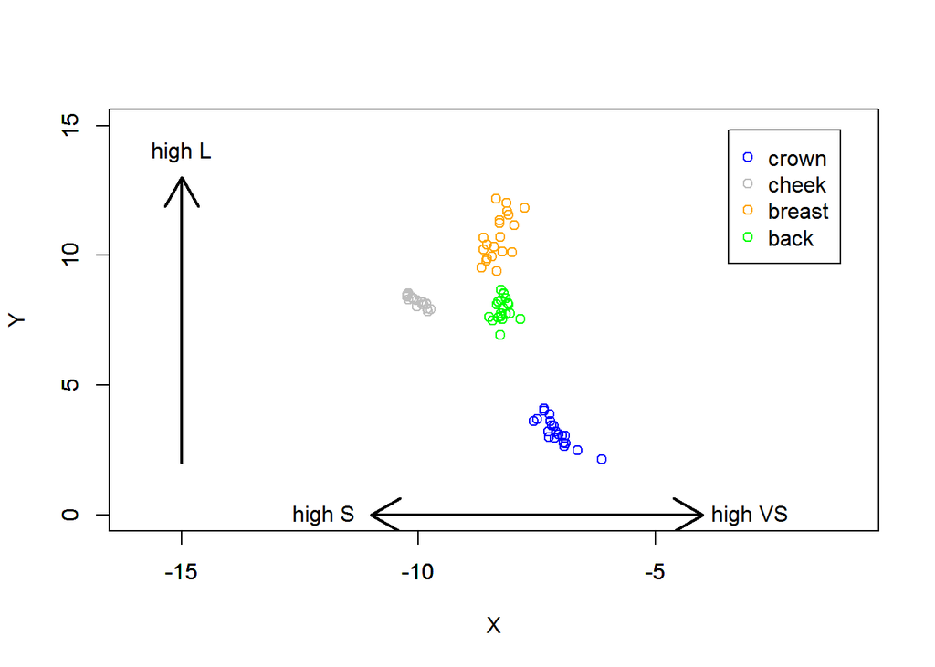

```r
bt.crown.s<-subset(blue.tit.snake, obs=="crown")
bt.cheek.s<-subset(blue.tit.snake, obs=="cheek")
bt.breast.s<-subset(blue.tit.snake, obs=="breast")
bt.back.s<-subset(blue.tit.snake, obs=="back")
#setting the scales of axes (note the scale should be the same)
max.range<-max(max(blue.tit.snake$x)-min(blue.tit.snake$x),max(blue.tit.snake$y)-min(blue.tit.snake$y))+5
lim.x<-c(mean(blue.tit.snake$x)-max.range/2,mean(blue.tit.snake$x)+max.range/2)
lim.y<-c(mean(blue.tit.snake$y)-max.range/2, mean(blue.tit.snake$y)+max.range/2)

plot(bt.crown.s$y~bt.crown.s$x, col="blue", xlim=lim.x, ylim=lim.y, xlab="X", ylab="Y")
par(fig=c(0,1,0,1), new=TRUE)
plot(bt.cheek.s$y~bt.cheek.s$x, col="grey", xlim=lim.x, ylim=lim.y, xlab="", ylab="")
par(fig=c(0,1,0,1), new=TRUE)
plot(bt.breast.s$y~bt.breast.s$x, col="orange", xlim=lim.x, ylim=lim.y, xlab="", ylab="")

par(fig=c(0,1,0,1), new=TRUE)
plot(bt.back.s$y~bt.back.s$x, col="green", xlim=lim.x, ylim=lim.y, xlab="", ylab="")

#add legend
legend("topright", legend=c("crown", "cheek", "breast", "back"), col=c("blue", "grey", "orange", "green"), pch=1, inset=0.05)

#adding arrows to interpret axes
text(x=-3, y=0, labels="high VS")
text(x=-12, y=0, labels="high S")
arrows(x0=-4, y0=0, x1=-11, y1=0, code=3, lwd=2)
text(x=-15, y=14, labels="high L")
arrows(x0=-15, x1=-15, y0=2, y1=13, code=2, lwd=2)
```

Following the approach described above one could compute PCA to determine the axes of chromatic variation in the two dimensional visual space of trichromats. This is not needed for dichromats that have only one chromatic dimension in their visual space.

# 3 Appendix S3: Colour variation in male mallard bill

## 3.1 Import bill reflectance spectra for 36 male mallards and run function “tetra”

```r
#imports matrix of mallard bill reflectance spectra (each spectrum in one row)
anas.ref <- read.csv("SuppInf_9_anas.ref.spec.csv")

anas.ref[1:6,1:10] #note that reflectance spectra are in rows
```

```
  duck.id wl300 wl305  wl310 wl315 wl320 wl325 wl330 wl335 wl340
1    x101 17.15 15.87 21.152 24.29 25.84 22.58 27.12 28.75 28.98
2    x104 22.33 27.41 31.990 31.70 34.12 35.30 33.12 33.43 34.99
3    x106 17.94 19.28 21.863 23.71 26.26 27.23 27.92 28.40 28.90
4    x108 18.43 21.10 20.752 24.18 25.86 28.33 29.18 30.79 30.11
5     x11  7.68 11.93  9.158 11.30 12.38 13.86 14.43 14.08 11.32
6    x114 13.14 13.83 23.657 25.07 25.29 27.42 26.05 27.88 25.53
```

Computing cone catches and xyz coordinates for mallard bill reflectances using the formulas in Appendix 1 (for more details see Appendix 2). You need to copy and paste the code in your R console to run the scripts first.

```r
#load irradiances
Irr5nm<-read.csv("SuppInf_5_Irr5nm.csv")

#load cone sensitivity functions (obtained with package "pavo", see Appendix S2)
duck.sens<-read.csv("SuppInf_11_duck.sens.csv")

#we used cone proportions of Anas penelope, the closest relative for which there is data (Hart 2001)
anas<-tetra(anas.ref, Tetra=duck.sens, pcones=c(0.2396694,0.5041322,1.0247934,1), Irr=Irr5nm, irrIrr=2, wlInclude=TRUE)

#having a look at the output
anas[1:6,1:18]
```

```
  duck.id wlResol        Irr     Tetra       conesProp
1    x101       5 Irr5nm$d65 duck.sens 0.24,0.5,1.02,1
2    x104       5 Irr5nm$d65 duck.sens 0.24,0.5,1.02,1
3    x106       5 Irr5nm$d65 duck.sens 0.24,0.5,1.02,1
4    x108       5 Irr5nm$d65 duck.sens 0.24,0.5,1.02,1
5     x11       5 Irr5nm$d65 duck.sens 0.24,0.5,1.02,1
6    x114       5 Irr5nm$d65 duck.sens 0.24,0.5,1.02,1
                  WeberFrac    VS      S     M     L      x      y     z
1 0.1021,0.0704,0.0494,0.05 7.711 12.246 20.43 20.60 -3.729  8.675 4.574
2 0.1021,0.0704,0.0494,0.05 9.764 16.640 28.31 29.84 -4.297  9.233 5.567
3 0.1021,0.0704,0.0494,0.05 8.215 12.982 19.37 19.82 -3.689  7.190 4.052
4 0.1021,0.0704,0.0494,0.05 7.900 12.505 22.27 22.35 -3.703  9.519 4.936
5 0.1021,0.0704,0.0494,0.05 3.433  5.454 11.08 11.64 -3.730 11.260 6.562
6 0.1021,0.0704,0.0494,0.05 7.046 11.162 20.57 21.06 -3.709  9.971 5.485
  wl300 wl305  wl310 wl315 wl320
1 17.15 15.87 21.152 24.29 25.84
2 22.33 27.41 31.990 31.70 34.12
3 17.94 19.28 21.863 23.71 26.26
4 18.43 21.10 20.752 24.18 25.86
5  7.68 11.93  9.158 11.30 12.38
6 13.14 13.83 23.657 25.07 25.29
```

The output includes columns documenting the visual parameters used (irradiance, visual sensitivities, cone proportions), cone quantum catches (VS:S:M:L), xyz coordinates and the reflectance spectra (between 300 and 700 nm).

## 3.2 Principal Component Analysis

Next, we summarize chromatic variation in xyz coordinates using Principal Component Analysis

```r
PCs<-princomp(~x+y+z, cor=FALSE, data=anas) #note cor=FALSE, to use a covariance matrix

unclass(loadings(PCs))  #component loadings
```

```
    Comp.1  Comp.2  Comp.3
x  0.06307 -0.6650  0.7442
y -0.81122 -0.4685 -0.3499
z -0.58133  0.5816  0.5690
```

```r
summary(PCs) #components SDs, variances and % of total variance
```

```
Importance of components:
                       Comp.1  Comp.2  Comp.3
Standard deviation     1.8017 0.32574 0.27018
Proportion of Variance 0.9477 0.03098 0.02131
Cumulative Proportion  0.9477 0.97869 1.00000
```

```r
#adding PCs as variables
anas$PC1<-PCs$scores[,1]
anas$PC2<-PCs$scores[,2]
anas$PC3<-PCs$scores[,3]


#range of variation of PCs
max(anas$PC1)-min(anas$PC1)
```

```
[1] 8.119
```

```r
max(anas$PC2)-min(anas$PC2)
```

```
[1] 1.246
```

```r
max(anas$PC3)-min(anas$PC3)
```

```
[1] 1.273
```

To facilitate plotting PCxyz lines we can compute xyz coordinates for PC1, PC2 and PC3 lines.

```r
PCload<- as.data.frame(unclass(loadings(PCs)))#computing xyz coordinates for PC1

#backcalculates XYZ values based on PC1.
anas$xPC1 <- with(anas, PC1*PCload[1,1]+mean(anas$x))
anas$yPC1 <- with(anas, PC1* PCload [2,1]+mean(anas$y))
anas$zPC1 <- with(anas, PC1* PCload [3,1]+mean(anas$z))

#we can do the same for PC2
#backcalculates xyz values for PC2
anas$xPC2 <- with(anas, PC2*PCload[1,2]+mean(anas$x))
anas$yPC2 <- with(anas, PC2* PCload [2,2]+mean(anas$y))
anas$zPC2 <- with(anas, PC2* PCload [3,2]+mean(anas$z))

#and PC3
#backcalculates xyz values for PC3
anas$xPC3 <- with(anas, PC3*PCload[1,3]+mean(anas$x))
anas$yPC3 <- with(anas, PC3* PCload [2,3]+mean(anas$y))
anas$zPC3 <- with(anas, PC3* PCload [3,3]+mean(anas$z))
```

## 3.3 Plotting in visual space

Next we can plot in the three-dimensional chromatic space using the package “rgl”

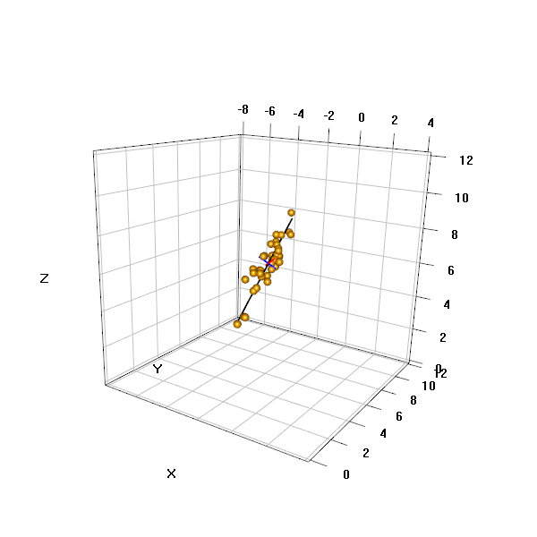

```r
#setting the limits for the xyz axes.
#Note that in order to keep uniform scaling of axes the range should be the same for each axis
lim.x<-c(-8, 4)
lim.y<-c(0, 12)
lim.z<-c(0,12)
#a scaffold to put axes on similar scales
plot3d(x=lim.x, y=lim.y, z=lim.z, type="n", aspect=TRUE, box=FALSE, xlab="X", ylab="Y", zlab="Z")

#adding the xyz coordinates
plot3d(x=anas$x, y=anas$y, z=anas$z, type="s", aspect=TRUE, box=FALSE, add=TRUE, col="orange")

#plotting PC1 line
plot3d(x=anas$xPC1, y=anas$yPC1, z=anas$zPC1, type="l", add=TRUE, lwd=2, col="black")

#plotting PC2 line
plot3d(x=anas$xPC2, y=anas$yPC2, z=anas$zPC2, type="l", add=TRUE, lwd=2, col="blue")

#plotting PC3 line
plot3d(x=anas$xPC3, y=anas$yPC3, z=anas$zPC3, type="l", add=TRUE, lwd=2, col="red")

#adds a grid
grid3d(c("x","y+","z"))
```

## 3.4 Relating chromatic variation to spectral shape

Next, we relate variation in spectral shape to PC1 and PC2. We start by computing and plotting average spectra for the four quartiles of PC1 and PC2 (note this can also be done for PC3 if deemed necessary).

First PC1:

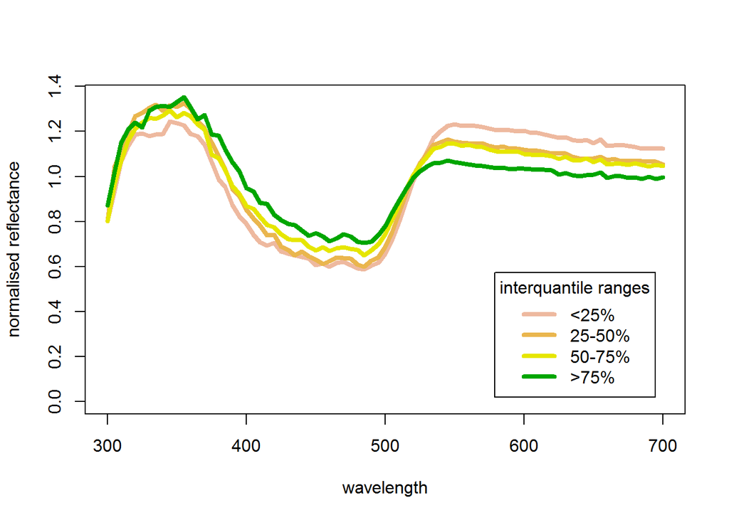

```r
#assigns the dataset to be used [to keep the code generic]
Data<-anas

#assigns interquantile ranges based on PC1 and PC2
anas$PC1q <-factor(1+(Data$PC1>quantile(Data$PC1, probs=0.25) & Data$PC1<=quantile(Data$PC1, probs=0.5))+2*(Data$PC1>quantile(Data$PC1, probs=0.5) & Data$PC1<=quantile(Data$PC1, probs=0.75))+3*(Data$PC1>quantile(Data$PC1, probs=0.75) & Data$PC1<=max(Data$PC1)))
anas$PC2q <-factor(1+(Data$PC2>quantile(Data$PC2, probs=0.25) & Data$PC2<=quantile(Data$PC2, probs=0.5))+2*(Data$PC2>quantile(Data$PC2, probs=0.5) & Data$PC2<=quantile(Data$PC2, probs=0.75))+3*(Data$PC2>quantile(Data$PC2, probs=0.75) & Data$PC2<=max(Data$PC2)))

#average spectra of the 4 interquantile ranges belonging to PC1 [note that we only select columns corresponding to reflectance spectra]
spectra<-(aggregate(anas[,14:94], by=list(q=anas$PC1q), mean)[,-1])

#transposing
spectra<-na.omit(as.data.frame(t(spectra)))

#creating a wavelength vector
wavelength<-seq(300,700,along=spectra$V1)

# setting a colour palette
col.pal<-terrain.colors(n=5)

#finds the max reflectance to adjust ylim automatically
ymax<-max(I(spectra$V1/mean(spectra$V1)), I(spectra$V2/mean(spectra$V2)), I(spectra$V3/mean(spectra$V3)), I(spectra$V4/mean(spectra$V4)))

#plots average spectra for each quartile
plot(I(spectra$V1/mean(spectra$V1))~wavelength, ylim=c(0, ymax), xlab="wavelength", ylab="normalised reflectance", pch=0, col="white")
par(fig=c(0,1,0,1), new=TRUE)
lines(loess(I(spectra$V1/mean(spectra$V1))~wavelength, span=0.99), ylim=c(0, ymax), xlab="wavelength", ylab="normalised reflectance", lwd=4, col=col.pal[4])
par(fig=c(0,1,0,1), new=TRUE)
lines(loess(I(spectra$V2/mean(spectra$V2))~wavelength, span=0.99), ylim=c(0, ymax), ylab="normalised reflectance", lwd=4, col=col.pal[3])
par(fig=c(0,1,0,1), new=TRUE)
lines(loess(I(spectra$V3/mean(spectra$V3))~wavelength, span=0.99), ylim=c(0, ymax), ylab="reflectance", lwd=4, col=col.pal[2])
par(fig=c(0,1,0,1), new=TRUE)
lines(loess(I(spectra$V4/mean(spectra$V4))~wavelength, span=0.99), ylim=c(0, ymax), ylab="reflectance", lwd=4, col=col.pal[1])
legend("bottomright", inset=0.05, title="interquantile ranges", c("<25%", "25-50%", "50-75%", ">75%"), lwd=c(4, 4, 4, 4), col=c(col.pal[4], col.pal[3], col.pal[2], col.pal[1]))
```

Reflectance spectra for each interquantile range can be linked to chromatic variation in the visual space. We can plot points in visual space using different colours for each interquantile range of PC1 which correspond to the average reflectance spectra depicted above.

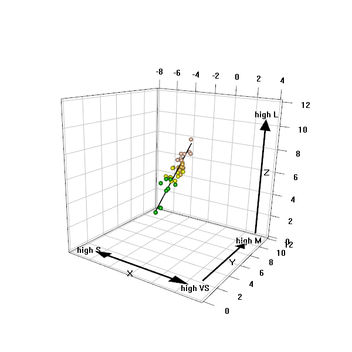

```r
#setting the limits for the xyz axes.
#Note that in order to keep uniform scaling of axes the range should be the same for each axis
lim.x<-c(-8, 4)
lim.y<-c(0, 12)
lim.z<-c(0,12)
#a scaffold to put axes on similar scales
plot3d(x=lim.x, y=lim.y, z=lim.z, type="n", aspect=TRUE, box=FALSE, xlab="", ylab="", zlab="")


plot3d(x=anas$x[anas$PC1q==1], y=anas$y[anas$PC1q==1], z=anas$z[anas$PC1q==1], type="s", radius=0.2, add=TRUE, col=col.pal[4])
plot3d(x=anas$x[anas$PC1q==2], y=anas$y[anas$PC1q==2], z=anas$z[anas$PC1q==2], type="s", radius=0.2, add=TRUE, col=col.pal[3])
plot3d(x=anas$x[anas$PC1q==3], y=anas$y[anas$PC1q==3], z=anas$z[anas$PC1q==3], type="s", radius=0.2, add=TRUE, col=col.pal[2])
plot3d(x=anas$x[anas$PC1q==4], y=anas$y[anas$PC1q==4], z=anas$z[anas$PC1q==4], type="s", radius=0.2, add=TRUE, col=col.pal[1])

#plots the PC1
plot3d(x=anas$xPC1, y=anas$yPC1, z=anas$zPC1, type="l", lwd=2, add=TRUE, col="black")

#adding extra info to the graph
#X axis and arrowheads
segments3d(x=c(-6,2), y=c(1,1), z=c(0,0), add=TRUE, lwd=3, add=TRUE)
triangles3d(x=c(-5,-5,-6.5), y=c(0.5,1.5,1), z=c(0,0,0), add=TRUE)
triangles3d(x=c(1,1,2.5), y=c(0.5,1.5,1), z=c(0,0,0), add=TRUE)
texts3d(x=3, y=1, z=0, texts="high VS")
texts3d(x=-7.1, y=1, z=0, texts="high S")
#X axis label
texts3d(x=-2, y=0, z=0, texts="X", font=1, cex=1)

#Y axis and arrowhead
segments3d(x=c(3,3), y=c(2,9), z=c(0,0), add=TRUE, lwd=3, add=TRUE)
triangles3d(x=c(2.5,3.5,3), y=c(8.5,8.5,9.5), z=c(0,0,0), add=TRUE)
text3d(x=3, y=10.5, z=0, texts="high M")
#Y axis label
texts3d(x=3.5, y=6, z=0, texts="Y", font=1, cex=1)

#Z axis and arrowhead
segments3d(x=c(3,3), y=c(12,12), z=c(0,10), add=TRUE, lwd=3, add=TRUE)
triangles3d(x=c(2.5,3.5,3), y=c(12,12,12), z=c(9.5,9.5,10.5), add=TRUE)
text3d(x=3, y=12, z=11, texts="high L")
texts3d(x=3.5, y=12, z=6, texts="Z", cex=1.5)

#adds a grid
grid3d(c("x","y+","z"))
```

Now we can repeat the same procedure with PC2:

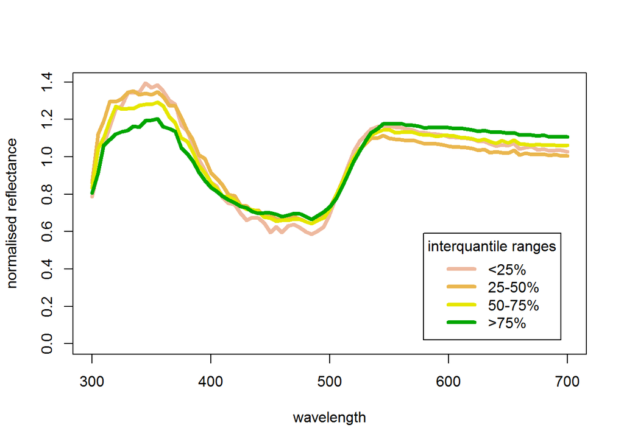

```r
#average spectra of the 4 interquantile ranges belonging to PC1
spectra<-(aggregate(anas[,14:94], by=list(q=anas$PC2q), mean)[,-1])

#transposing
spectra<-na.omit(as.data.frame(t(spectra)))

#creating a wavelength vector
wavelength<-seq(300,700,along=spectra$V1)

# setting a colour palette
col.pal<-terrain.colors(n=5)

#finds the max reflectance to adjust ylim automatically
ymax<-max(I(spectra$V1/mean(spectra$V1)), I(spectra$V2/mean(spectra$V2)), I(spectra$V3/mean(spectra$V3)), I(spectra$V4/mean(spectra$V4)))

plot(I(spectra$V1/mean(spectra$V1))~wavelength, ylim=c(0, ymax), xlab="wavelength", ylab="normalised reflectance", pch=0, col="white")
par(fig=c(0,1,0,1), new=TRUE)
lines(loess(I(spectra$V1/mean(spectra$V1))~wavelength, span=0.99), ylim=c(0, ymax), xlab="wavelength", ylab="normalised reflectance", lwd=4, col=col.pal[4])
par(fig=c(0,1,0,1), new=TRUE)
lines(loess(I(spectra$V2/mean(spectra$V2))~wavelength, span=0.99), ylim=c(0, ymax), ylab="normalised reflectance", lwd=4, col=col.pal[3])
par(fig=c(0,1,0,1), new=TRUE)
lines(loess(I(spectra$V3/mean(spectra$V3))~wavelength, span=0.99), ylim=c(0, ymax), ylab="reflectance", lwd=4, col=col.pal[2])
par(fig=c(0,1,0,1), new=TRUE)
lines(loess(I(spectra$V4/mean(spectra$V4))~wavelength, span=0.99), ylim=c(0, ymax), ylab="reflectance", lwd=4, col=col.pal[1])
legend("bottomright", inset=0.05, title="interquantile ranges", c("<25%", "25-50%", "50-75%", ">75%"), lwd=c(4, 4, 4, 4), col=c(col.pal[4], col.pal[3], col.pal[2], col.pal[1]))
```

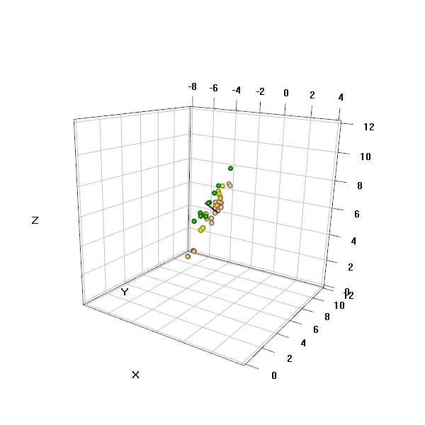

```r
#setting the limits for the xyz axes.
#Note that in order to keep uniform scaling of axes the range should be the same for each axis
lim.x<-c(-8, 4)
lim.y<-c(0, 12)
lim.z<-c(0,12)
#a scaffold to put axes on similar scales
plot3d(x=lim.x, y=lim.y, z=lim.z, type="n", aspect=TRUE, box=FALSE, xlab="X", ylab="Y", zlab="Z")


plot3d(x=anas$x[anas$PC2q==1], y=anas$y[anas$PC2q==1], z=anas$z[anas$PC2q==1], type="s", radius=0.2, add=TRUE, col=col.pal[4])
plot3d(x=anas$x[anas$PC2q==2], y=anas$y[anas$PC2q==2], z=anas$z[anas$PC2q==2], type="s", radius=0.2, add=TRUE, col=col.pal[3])
plot3d(x=anas$x[anas$PC2q==3], y=anas$y[anas$PC2q==3], z=anas$z[anas$PC2q==3], type="s", radius=0.2, add=TRUE, col=col.pal[2])
plot3d(x=anas$x[anas$PC2q==4], y=anas$y[anas$PC2q==4], z=anas$z[anas$PC2q==4], type="s", radius=0.2, add=TRUE, col=col.pal[1])

#plots the PC2
plot3d(x=anas$xPC2, y=anas$yPC2, z=anas$zPC2, type="l", lwd=2, add=TRUE, col="black")

#adds a grid
grid3d(c("x","y+","z"))
```

Suggests that PC2xyz represents relative UV reflectance (see Peters et al. 2004).

## 3.5 Correlations with male quality

Finally, we can assess whether PCxyz correlate with PCref as computed in Peters et al. (2004) and with immune titre. Import the data from Peters et al (2004) and merge it with the new colour analysis:

```r
anas.immune.data<-read.csv("SuppInf_10_anas.immune.data.csv")

head(anas.immune.data)
```

```
   id duck Titer  PC1ref   PC2ref   PC3ref
1  x3    3   3.0  0.0158 -2.17434  0.01691
2  x6    6   4.5 -1.4102 -0.21402 -0.76999
3 x11   11   0.0 -1.6837 -0.67277 -0.37283
4 x31   31   0.0  0.2939 -1.44901  1.63428
5 x42   42   0.0 -0.4956 -0.11700  0.81406
6 x44   44   4.0 -2.3147 -0.09353 -1.32057
```

```r
anas.c<-merge(x=anas, y=anas.immune.data, by.x="duck.id", by.y="id")
```

Here Titer refers to immune titre in response to a sheep red blood cell injection, while PC1ref, PC2ref and PC3ref correspond to the first three principal components computed on reflectance spectra.

Some scatterplots and correlations

PC1xyz correlates with PC2ref…

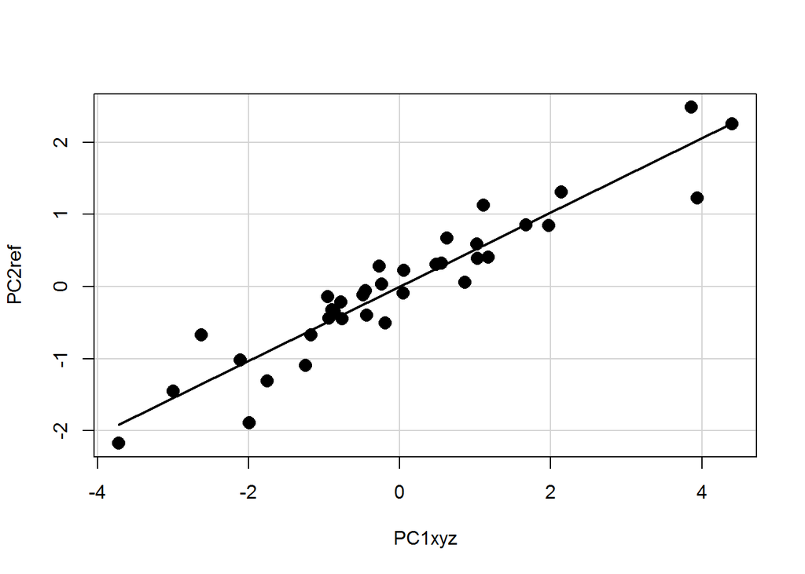

```r
require(car)
scatterplot(PC2ref~PC1, data=anas.c, smooth=FALSE, lwd=2,  col="black", pch=16, cex=1.5, boxplot=FALSE, ylab="PC2ref", xlab="PC1xyz")
```

```r
cor.test(x=anas.c$PC2ref, y=anas.c$PC1)
```

```
    Pearson's product-moment correlation

data:  anas.c$PC2ref and anas.c$PC1
t = 16.33, df = 34, p-value < 2.2e-16
alternative hypothesis: true correlation is not equal to 0
95 percent confidence interval:
 0.8880 0.9701
sample estimates:
   cor
0.9418
```

…but not with PC3ref.

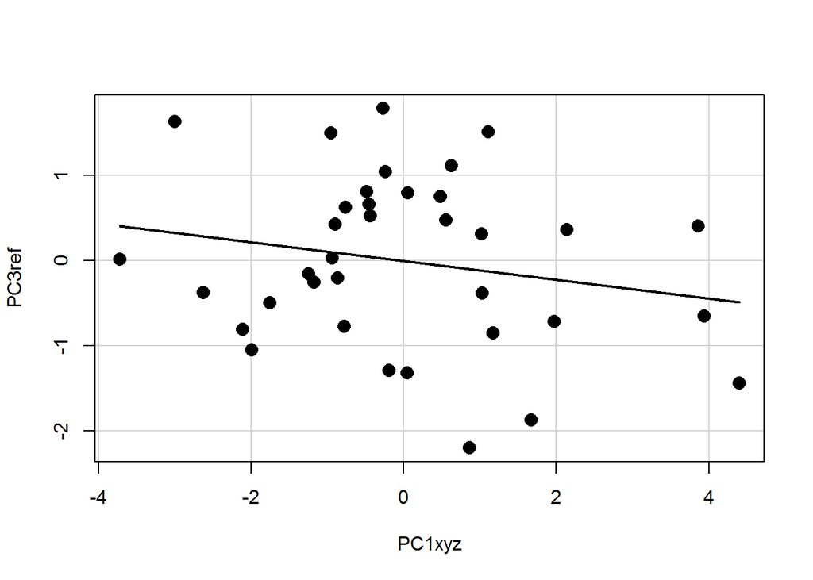

```r
scatterplot(PC3ref~PC1, data=anas.c, smooth=FALSE, lwd=2,  col="black", pch=16, cex=1.5, boxplot=FALSE, ylab="PC3ref", xlab="PC1xyz")
```

```r
cor.test(x=anas.c$PC3ref, y=anas.c$PC1)
```

```
    Pearson's product-moment correlation

data:  anas.c$PC3ref and anas.c$PC1
t = -1.198, df = 34, p-value = 0.2393
alternative hypothesis: true correlation is not equal to 0
95 percent confidence interval:
 -0.4969  0.1363
sample estimates:
    cor
-0.2012
```

PC2xyz correlates with PC3 ref…

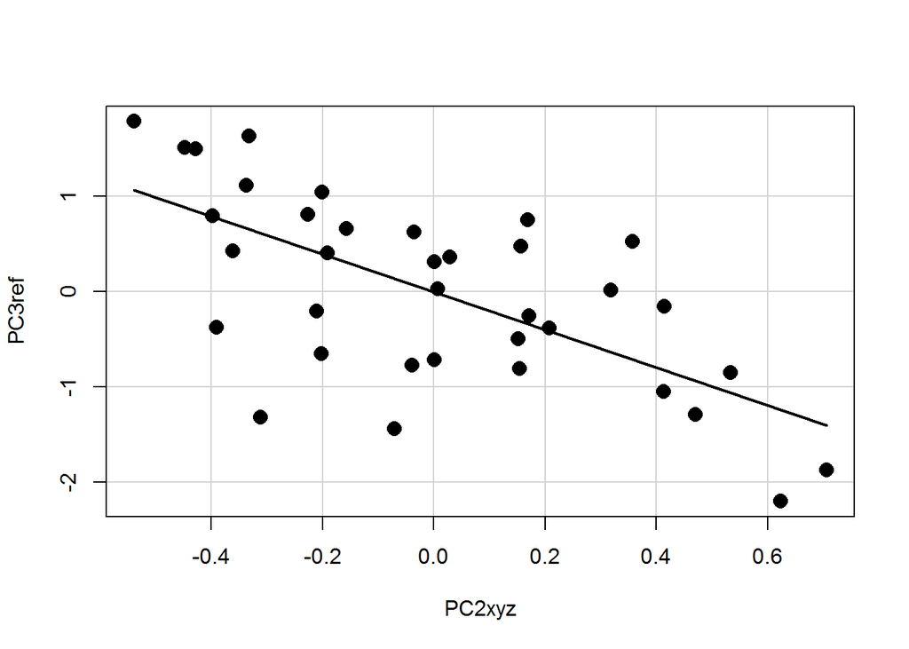

```r
scatterplot(PC3ref~PC2, data=anas.c, smooth=FALSE, lwd=2,  col="black", pch=16, cex=1.5, boxplot=FALSE, ylab="PC3ref", xlab="PC2xyz")
```

```r
cor.test(x=anas.c$PC3ref, y=anas.c$PC2)
```

```
    Pearson's product-moment correlation

data:  anas.c$PC3ref and anas.c$PC2
t = -5.05, df = 34, p-value = 1.478e-05
alternative hypothesis: true correlation is not equal to 0
95 percent confidence interval:
 -0.8092 -0.4156
sample estimates:
    cor
-0.6547
```

…but not with PC2 ref.

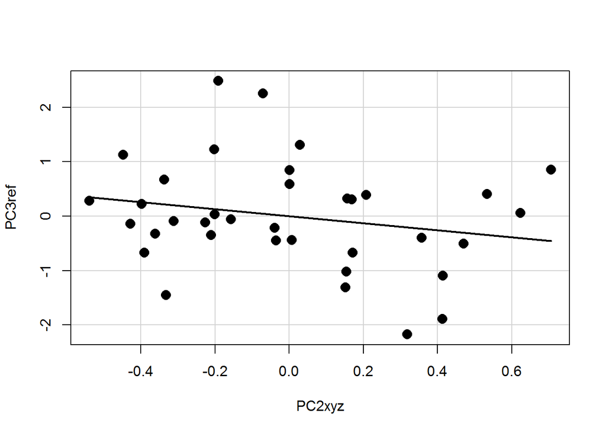

```r
scatterplot(PC2ref~PC2, data=anas.c, smooth=FALSE, lwd=2,  col="black", pch=16, cex=1.5, boxplot=FALSE, ylab="PC3ref", xlab="PC2xyz")
```

```r
cor.test(x=anas.c$PC2ref, y=anas.c$PC2)
```

```
    Pearson's product-moment correlation

data:  anas.c$PC2ref and anas.c$PC2
t = -1.28, df = 34, p-value = 0.2093
alternative hypothesis: true correlation is not equal to 0
95 percent confidence interval:
 -0.5072  0.1228
sample estimates:
    cor
-0.2144
```

PC1xyz does not correlate with immune titre…

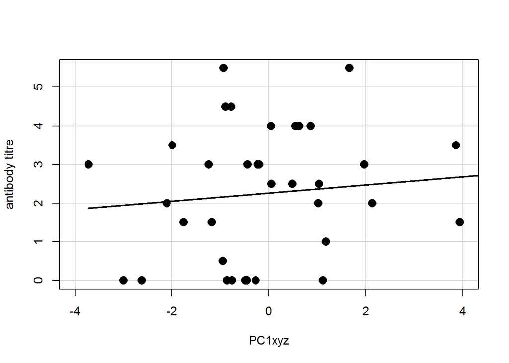

```r
scatterplot(Titer~PC1, data=anas.c, smooth=FALSE, lwd=2, xlim=c(-4,4), col="black", pch=16, cex=1.5, boxplot=FALSE, ylab="antibody titre", xlab="PC1xyz")
```

```r
cor.test(data=anas.c, x=anas.c$Titer, y=anas.c$PC1)
```

```
    Pearson's product-moment correlation

data:  anas.c$Titer and anas.c$PC1
t = 0.6733, df = 34, p-value = 0.5053
alternative hypothesis: true correlation is not equal to 0
95 percent confidence interval:
 -0.2222  0.4272
sample estimates:
   cor
0.1147
```

…but PC2xyz does (however, note the scale of the x axis!)

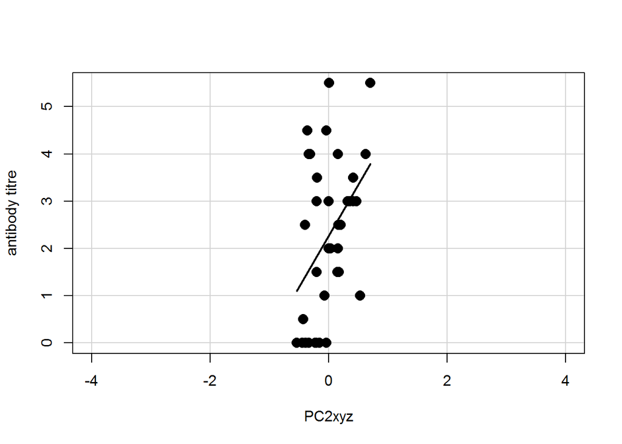

```r
scatterplot(Titer~PC2, data=anas.c, smooth=FALSE, lwd=2,  col="black",xlim=c(-4,4), pch=16, cex=1.5, boxplot=FALSE, ylab="antibody titre", xlab="PC2xyz")
```

```r
cor.test(data=anas.c, x=anas.c$Titer, y=anas.c$PC2)
```

```
    Pearson's product-moment correlation

data:  anas.c$Titer and anas.c$PC2
t = 2.73, df = 34, p-value = 0.009965
alternative hypothesis: true correlation is not equal to 0
95 percent confidence interval:
 0.1109 0.6605
sample estimates:
  cor
0.424
```

## 3.6 Multivariate Analyses

Aspects of chromatic variation that correlate with immune titre may not necessarily be the same as those captured by the PCs.This can be tested with a MANOVA, where xyz coordinates are the three response variables and titre the independent variable.

```r
#Manova
m1<-manova(cbind(x,y,z)~Titer, data=anas.c)
summary(m1)
```

```
          Df Pillai approx F num Df den Df Pr(>F)
Titer      1  0.283     4.21      3     32  0.013 *
Residuals 34
---
Signif. codes:  0 '***' 0.001 '**' 0.01 '*' 0.05 '.' 0.1 ' ' 1
```

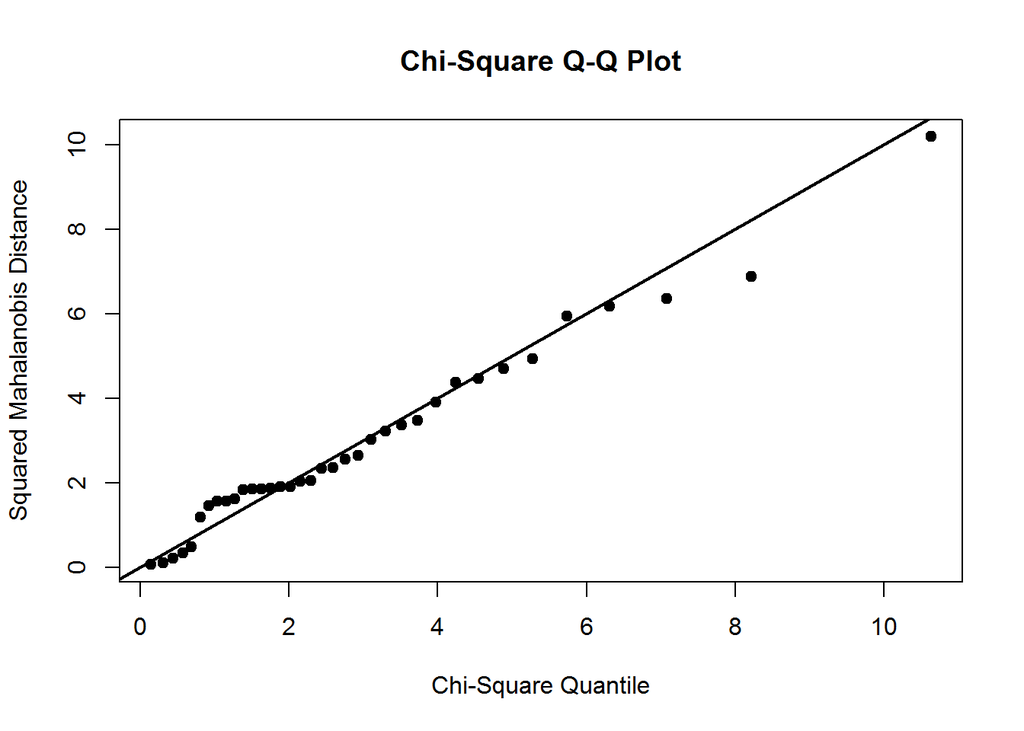

```
  Royston's Multivariate Normality Test
---------------------------------------------
  data : resid(m1)

  H       : 3.268
  p-value : 0.212

  Result  : Data is multivariate normal.
---------------------------------------------
```

```r
#Multivariate normality of residuals
require(MVN)
roystonTest(data=resid(m1), qqplot=TRUE)
```

```r
hzTest(data=resid(m1), qqplot=FALSE)
```

```
  Henze-Zirkler's Multivariate Normality Test
---------------------------------------------
  data : resid(m1)

  HZ      : 0.6133
  p-value : 0.5062

  Result  : Data is multivariate normal.
---------------------------------------------
```

```r
mardiaTest(data=resid(m1), qqplot=FALSE)
```

```
   Mardia's Multivariate Normality Test
---------------------------------------
   data : resid(m1)

   g1p            : 1.569
   chi.skew       : 9.412
   p.value.skew   : 0.4935

   g2p            : 13.96
   z.kurtosis     : -0.5718
   p.value.kurt   : 0.5675

   chi.small.skew : 10.63
   p.value.small  : 0.3873

   Result         : Data is multivariate normal.
---------------------------------------
```

Residuals seem to roughly follow a normal distribution.

Predicting xyz coordinates for each immune titre based on the model.

```r
anas.c$x.pre<-predict(m1)[,1]
anas.c$y.pre<-predict(m1)[,2]
anas.c$z.pre<-predict(m1)[,3]
```

Computing chromatic distance between points at the extremes of the immune titre range based on predicted xyz values.

```r
min.T=subset(anas.c, Titer==min(anas.c$Titer))
max.T=subset(anas.c, Titer==max(anas.c$Titer))
sqrt((mean(max.T$x.pre)-mean(min.T$x.pre))^2+(mean(max.T$y.pre)-mean(min.T$y.pre))^2+(mean(max.T$z.pre)-mean(min.T$z.pre))^2)
```

```
[1] 0.8683
```

Plotting the predicted line in green (together with the PC1-3 lines for comparison). To make these lines more visible we have ommited plotting the xyz coordinates for each male’s bill colour.

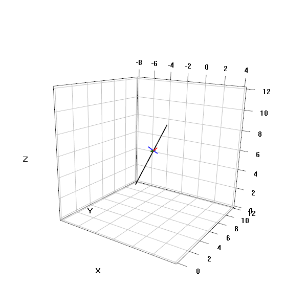

```r
#setting the limits for the xyz axes.
#Note that in order to keep uniform scaling of axes the range should be the same for each axis
lim.x<-c(-8, 4)
lim.y<-c(0, 12)
lim.z<-c(0,12)
#a scaffold to put axes on similar scales
plot3d(x=lim.x, y=lim.y, z=lim.z, type="n", aspect=TRUE, box=FALSE, xlab="X", ylab="Y", zlab="Z")


#plotting PC1 line
plot3d(x=anas$xPC1, y=anas$yPC1, z=anas$zPC1, type="l", add=TRUE, lwd=2, col="black")

#plotting PC2 line
plot3d(x=anas$xPC2, y=anas$yPC2, z=anas$zPC2, type="l", add=TRUE, lwd=2, col="blue")

#plotting PC3 line
plot3d(x=anas$xPC3, y=anas$yPC3, z=anas$zPC3, type="l", add=TRUE, lwd=2, col="red")

#plotting the manova predicted line
plot3d(x=anas.c$x.pre, y=anas.c$y.pre, z=anas.c$z.pre, type="l", add=TRUE, lwd=3, col="dark green")

#adds a grid
grid3d(c("x","y+","z"))
```

# 4 Appendix S4 - Assessing the effects of varying irradiance and cone proportions

```r
#imports matrix of mallard bill reflectance spectra (each spectrum in one row)
anas.ref <- read.csv("SuppInf_9_anas.ref.spec.csv")

#import immune data
anas.immune.data<-read.csv("SuppInf_10_anas.immune.data.csv")

#import cone proportions
cone.proportions <- read.csv("SuppInf_12_cone.proportions.csv")

#load irradiances
Irr5nm<-read.csv("SuppInf_5_Irr5nm.csv")

#load cone sensitivity functions (obtained with package "pavo", see Appendix 1)
duck.sens<-read.csv("SuppInf_11_duck.sens.csv")

#loop starts here
#creating an output data frame
res.output<-as.data.frame(matrix(ncol=8, nrow=1))
colnames(res.output)<-c("i","pc", "sd","irr",  "var.prop",  "range", "cor.PC",  "cor.titre")
res.output<-res.output[-1,]

#cone.proportions vector (list of species codes to be retrieved from PTetra.V)
species.code<-c("Aaff",  "Apen",  "Amin",  "Lnov",  "Schi", "Tsan", "Esco", "Pcri", "Gten", "Ecya", "Mmel", "Pvio", "Svul", "Tmer", "Pcae", "Pvar", "Ppac", "Cros", "Mund", "Pexi", "Tchl", "Thae")

#Codes and scientific names. Nomenclature follows Hart 2001 J Comp Physiol A 187:685-698.

#Aaff=Aythya affinis; Apen=Anas penelope; Amin=Anous minutus; Lnov=Larus novaehollandiae;
#Schi=Streptopelia chinensis; Tsan=Todiramphus sanctus; Esco=Eudynamys scolopacea;
#Pcri=Pavo cristatus; Gten=Gallinula tenebrosa; Ecya=Entomyzon cyanotis;
#Mmel=Manorina melanocephala; Pvio=Ptilonorhynchus violaceus; Svul=Sturnus vulgaris;
#Tmer=Turdus merula; Pcae=Parus caeruleus; Pvar=Phalacrocorax varius; Ppac=Puffinus pacificus;
#Cros=Cacatua roseicapilla; Mund=Melopsittacus undulatus; Pexi=Platycercus eximius;
#Tchl=Trichoglossus chlorolepidotus; Thae=Trichoglossus haematodus



#for loop that:
#(1) runs function tetra with each combination of irradiance (d65, forest shade and woodland shade)
#(2) computes PCA
#(3) stores proportion of variance explained by PCs, their absolute range, correlation with PCref and immune titre
for (i in species.code){

cone.prop<-subset(cone.proportions, taxon==i)

anas<-tetra(anas.ref, Tetra=duck.sens, pcones=cone.prop[,2:5], Irr=Irr5nm, irrIrr=2, wlInclude=TRUE)
anas<-merge(x=anas, y=anas.immune.data, by.x="duck.id", by.y="id")
PCs<-princomp(~x+y+z, cor=FALSE, data=anas)

sd<-PCs$sdev
var.prop<-sd^2/sum(sd^2)
range<-c(max(PCs$scores[,1])-min(PCs$scores[,1]),max(PCs$scores[,2])-min(PCs$scores[,2]),max(PCs$scores[,3])-min(PCs$scores[,3]))
cor.PC<-c(cor(PCs$scores[,1],anas$PC2ref),cor(PCs$scores[,2],anas$PC3ref),cor(PCs$scores[,3],anas$PC3ref))
cor.titre<-c(cor(PCs$scores[,1],anas$Titer),cor(PCs$scores[,2],anas$Titer),cor(PCs$scores[,3],anas$Titer))
pc<-c("PC1", "PC2", "PC3")
irr<-"d65"
out<-data.frame(i,pc,irr,sd,var.prop,range,cor.PC,cor.titre)

res.output<-rbind(res.output,out)

#using forest shade
anas<-tetra(anas.ref, Tetra=duck.sens, pcones=cone.prop[,2:5], Irr=Irr5nm, irrIrr=3, wlInclude=TRUE)

PCs<-princomp(~x+y+z, cor=FALSE, data=anas) #note cor=FALSE, to use a covariance matrix

anas<-merge(x=anas, y=anas.immune.data, by.x="duck.id", by.y="id")
PCs<-princomp(~x+y+z, cor=FALSE, data=anas)

sd<-PCs$sdev
var.prop<-sd^2/sum(sd^2)
range<-c(max(PCs$scores[,1])-min(PCs$scores[,1]),max(PCs$scores[,2])-min(PCs$scores[,2]),max(PCs$scores[,3])-min(PCs$scores[,3]))
cor.PC<-c(cor(PCs$scores[,1],anas$PC2ref),cor(PCs$scores[,2],anas$PC3ref),cor(PCs$scores[,3],anas$PC3ref))
cor.titre<-c(cor(PCs$scores[,1],anas$Titer),cor(PCs$scores[,2],anas$Titer),cor(PCs$scores[,3],anas$Titer))
pc<-c("PC1", "PC2", "PC3")
irr<-"forest.shade"
out<-data.frame(i,pc,irr,sd,var.prop,range,cor.PC,cor.titre)

res.output<-rbind(res.output,out)
#using woodland shade
anas<-tetra(anas.ref, Tetra=duck.sens, pcones=cone.prop[,2:5], Irr=Irr5nm, irrIrr=4, wlInclude=TRUE)

anas<-merge(x=anas, y=anas.immune.data, by.x="duck.id", by.y="id")
PCs<-princomp(~x+y+z, cor=FALSE, data=anas)

sd<-PCs$sdev
var.prop<-sd^2/sum(sd^2)
range<-c(max(PCs$scores[,1])-min(PCs$scores[,1]),max(PCs$scores[,2])-min(PCs$scores[,2]),max(PCs$scores[,3])-min(PCs$scores[,3]))
cor.PC<-c(cor(PCs$scores[,1],anas$PC2ref),cor(PCs$scores[,2],anas$PC3ref),cor(PCs$scores[,3],anas$PC3ref))
cor.titre<-c(cor(PCs$scores[,1],anas$Titer),cor(PCs$scores[,2],anas$Titer),cor(PCs$scores[,3],anas$Titer))
pc<-c("PC1", "PC2", "PC3")
irr<-"woodland.shade"
out<-data.frame(i,pc,irr,sd,var.prop,range,cor.PC,cor.titre)

res.output<-rbind(res.output,out)

}

head(res.output)
```

```
           i  pc          irr     sd var.prop range  cor.PC cor.titre
Comp.1  Aaff PC1          d65 1.8959  0.95136 8.549  0.9394    0.1169
Comp.2  Aaff PC2          d65 0.3321  0.02918 1.247  0.5912   -0.3782
Comp.3  Aaff PC3          d65 0.2711  0.01946 1.243 -0.4927    0.3555
Comp.11 Aaff PC1 forest.shade 1.8390  0.94890 8.299  0.9451    0.1073
Comp.21 Aaff PC2 forest.shade 0.3277  0.03012 1.340  0.5279   -0.3370
Comp.31 Aaff PC3 forest.shade 0.2734  0.02098 1.209 -0.5673    0.3994
```

```r
#excluding the used cone proportions (those from Anas penelope) from this summary
res.out.pc1<-subset(res.output, pc=="PC1" & i!="Apen")
res.out.pc2<-subset(res.output, pc=="PC2"& i!="Apen")

#proportion of the chromatic variance explained by PC1xyz
summary(res.out.pc1$var.prop)
```

```
   Min. 1st Qu.  Median    Mean 3rd Qu.    Max.
  0.930   0.937   0.947   0.945   0.950   0.960
```

```r
#absolute range of PC1xyz
summary(res.out.pc1$range)
```

```
   Min. 1st Qu.  Median    Mean 3rd Qu.    Max.
   6.12    8.35    9.15    8.98    9.51   13.00
```

```r
#correlation between PC1xyz and PC2ref
summary(res.out.pc1$cor.PC)
```

```
   Min. 1st Qu.  Median    Mean 3rd Qu.    Max.
  0.925   0.942   0.946   0.945   0.948   0.957
```

```r
#correlation between PC1xyz and immune titre
summary(res.out.pc1$cor.titre)
```

```
   Min. 1st Qu.  Median    Mean 3rd Qu.    Max.
 0.0765  0.1050  0.1090  0.1100  0.1160  0.1500
```

```r
#proportion of the chromatic variance explained by PC2xyz
summary(res.out.pc2$var.prop)
```

```
   Min. 1st Qu.  Median    Mean 3rd Qu.    Max.
 0.0247  0.0316  0.0336  0.0369  0.0448  0.0545
```

```r
#absolute range of PC2xyz
summary(res.out.pc2$range)
```

```
   Min. 1st Qu.  Median    Mean 3rd Qu.    Max.
   1.05    1.40    1.79    1.75    2.02    2.82
```

```r
#correlation between PC2xyz and PC3ref
summary(abs(res.out.pc2$cor.PC))
```

```
   Min. 1st Qu.  Median    Mean 3rd Qu.    Max.
  0.263   0.361   0.471   0.474   0.543   0.768
```

```r
#correlation between PC2xyz and immune titre
summary(abs(res.out.pc2$cor.titre))
```

```
   Min. 1st Qu.  Median    Mean 3rd Qu.    Max.
  0.151   0.218   0.270   0.288   0.328   0.515
```

# 5 Appendix S5: Assessing colour manipulations in blue tits

We start by importing the pre-manipulation reflectance spectra to assess natural chromatic variation in visual space.

```r
bt.pre.ref<-read.csv("SuppInf_6_bt.pre.crw.csv") #note reflectance spectra are in rows

head(bt.pre.ref[,1:5])
```

```
      ind wl300 wl305 wl310 wl315
1 B1G9014 29.80 35.89 40.24 44.51
2 B1G9065 28.86 33.63 37.93 42.60
3 B1G9067 27.17 30.37 37.74 42.81
4 B1G9088 25.45 26.91 31.88 35.71
5 B1G9203 23.25 24.31 28.04 29.38
6 B1G9210 23.74 25.43 29.07 32.64
```

## 5.1 Running function “tetra”

Computing cone catches and xyz coordinates for blue tit crown reflectance using the formulas in Cassey et al. (2008) implemented in Appendix 1. Note that these functions need to be run first. Also make sure that you install packages “plyr”, “reshape2”, “rgl” and “pavo”.

```r
#load irradiances
#load irradiances
Irr5nm<-read.csv("SuppInf_5_Irr5nm.csv")

#compute cone sensitivity functions for blue tits (see Appendix 1 and 2 for more details)
require(pavo)
bt.sens <- sensmodel(c(371,448,502,563),beta=F,lambdacut=c(330,413,507,572), oiltype = c("T", "C", "Y","R"),om= TRUE)


bt.pre<-tetra(bt.pre.ref, Tetra=bt.sens, pcones=c(0.3743842,0.7093596,1,1), Irr=Irr5nm, irrIrr=2, wlInclude=TRUE)

head(bt.pre[,1:18])
```

```
      ind wlResol        Irr   Tetra     conesProp               WeberFrac
1 B1G9014       5 Irr5nm$d65 bt.sens 0.37,0.71,1,1 0.0817,0.0594,0.05,0.05
2 B1G9065       5 Irr5nm$d65 bt.sens 0.37,0.71,1,1 0.0817,0.0594,0.05,0.05
3 B1G9067       5 Irr5nm$d65 bt.sens 0.37,0.71,1,1 0.0817,0.0594,0.05,0.05
4 B1G9088       5 Irr5nm$d65 bt.sens 0.37,0.71,1,1 0.0817,0.0594,0.05,0.05
5 B1G9203       5 Irr5nm$d65 bt.sens 0.37,0.71,1,1 0.0817,0.0594,0.05,0.05
6 B1G9210       5 Irr5nm$d65 bt.sens 0.37,0.71,1,1 0.0817,0.0594,0.05,0.05
      VS     S     M     L      x      y      z wl300 wl305 wl310 wl315
1 11.318 33.49 24.17 17.59 -10.74 0.7008 -4.812 29.80 35.89 40.24 44.51
2 11.167 33.97 24.97 17.74 -11.02 1.1042 -4.971 28.86 33.63 37.93 42.60
3 11.419 36.48 27.87 19.87 -11.50 1.9013 -4.432 27.17 30.37 37.74 42.81
4  9.437 29.75 23.33 17.90 -11.37 2.2147 -3.040 25.45 26.91 31.88 35.71
5  6.741 19.17 13.95 10.75 -10.35 0.6250 -3.914 23.25 24.31 28.04 29.38
6  7.882 23.02 17.08 13.19 -10.61 1.0353 -3.640 23.74 25.43 29.07 32.64
  wl320
1 48.53
2 46.87
3 45.46
4 37.99
5 31.12
6 34.43
```

The output includes columns documenting the visual parameters used (irradiance, visual sensitivities, cone proportions), cone quantum catches (VS:S:M:L), xyz coordinates and the reflectance spectra (between 300 and 700 nm).

## 5.2 Principal Component Analysis

Next we summarize chromatic variation in xyz coordinates using Principal Component Analysis.

```r
PCs<-princomp(~x+y+z, cor=FALSE, data=bt.pre) #note cor=FALSE, to use a covariance matrix
unclass(loadings(PCs))  #component loadings
```

```
   Comp.1  Comp.2  Comp.3
x  0.3019  0.5724  0.7624
y -0.6756 -0.4358  0.5947
z -0.6726  0.6946 -0.2551
```

```r
summary(PCs) #component SDs and variances
```

```
Importance of components:
                       Comp.1  Comp.2  Comp.3
Standard deviation     1.4819 0.40622 0.08706
Proportion of Variance 0.9271 0.06967 0.00320
Cumulative Proportion  0.9271 0.99680 1.00000
```

```r
#adding PCs as variables
bt.pre$PC1<-PCs$scores[,1]
bt.pre$PC2<-PCs$scores[,2]
bt.pre$PC3<-PCs$scores[,3]
```

Means of xyz coordinates should also be reported to enable projection of other data on the same PC axes (see below).

```r
mean(bt.pre$x)
```

```
[1] -10.94
```

```r
mean(bt.pre$y)
```

```
[1] 1.343
```

```r
mean(bt.pre$z)
```

```
[1] -4.031
```

To facilitate plotting PCxyz lines we can compute xyz coordinates for PC1 line

```r
#computing xyz coordinates for PC1
PCload<- as.data.frame(unclass(loadings(PCs)))
#backcalculates XYZ values based on PC1.

bt.pre$xPC1 <- with(bt.pre, PC1*PCload[1,1]+mean(bt.pre$x))

bt.pre$yPC1 <- with(bt.pre, PC1* PCload [2,1]+mean(bt.pre$y))

bt.pre$zPC1 <- with(bt.pre, PC1* PCload [3,1]+mean(bt.pre$z))
```

## 5.3 Plotting pre-manipulation colour in visual space

Next, we plot xyz coordinates and PC1 line in visual space using the package “rgl”

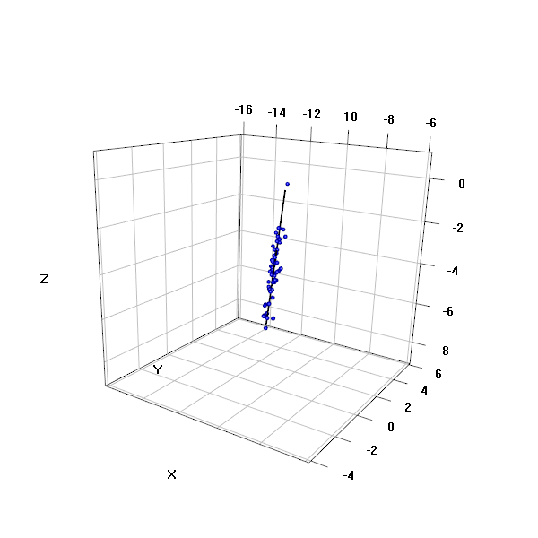

```r
require(rgl)

#setting the limits for the xyz axes.
#Note that in order to keep uniform scaling of axes the range should be the same for each axis
lim.x<-c(-16, -6)
lim.y<-c(-4, 6)
lim.z<-c(-9,1)
#a scaffold to put axes on similar scales
plot3d(x=lim.x, y=lim.y, z=lim.z, type="n", aspect=TRUE, box=FALSE, xlab="X", ylab="Y", zlab="Z")

plot3d(x=bt.pre$x, y=bt.pre$y, z=bt.pre$z, type="s", radius=0.1, add=TRUE, col="blue")

plot3d(x=bt.pre$xPC1, y=bt.pre$yPC1, z=bt.pre$zPC1, type="l", lwd=2, add=TRUE, col="black") #PC1 line

#adds a grid
grid3d(c("x","y+","z"))
```

## 5.4 Relating chromatic variation to spectral shape

Now, we relate variation in spectral shape to PC1. We start by computing and plotting average spectra for the four quantiles of PC1.

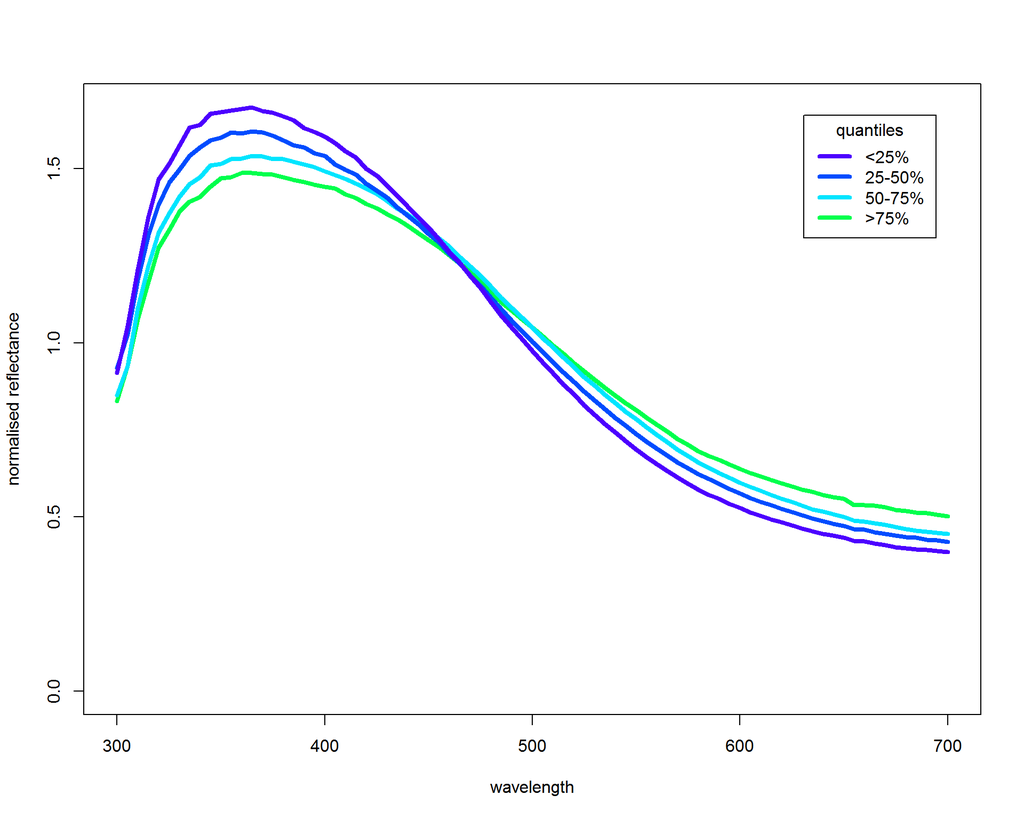

```r
#assigns the dataset to be used
Data<-bt.pre
#computes quantiles on PC1 and PC2
Data$PC1q <-factor(1+(Data$PC1>quantile(Data$PC1, probs=0.25) & Data$PC1<=quantile(Data$PC1, probs=0.5))+2*(Data$PC1>quantile(Data$PC1, probs=0.5) & Data$PC1<=quantile(Data$PC1, probs=0.75))+3*(Data$PC1>quantile(Data$PC1, probs=0.75) & Data$PC1<=max(Data$PC1)))
Data$PC2q <-factor(1+(Data$PC2>quantile(Data$PC2, probs=0.25) & Data$PC2<=quantile(Data$PC2, probs=0.5))+2*(Data$PC2>quantile(Data$PC2, probs=0.5) & Data$PC2<=quantile(Data$PC2, probs=0.75))+3*(Data$PC2>quantile(Data$PC2, probs=0.75) & Data$PC2<=max(Data$PC2)))

bt.pre$PC1q<-Data$PC1q

#average spectra of the 4 quantiles belonging to PC1
spectra<-(aggregate(bt.pre[,14:94], by=list(q=Data$PC1q), mean)[,-1])

spectra<-na.omit(as.data.frame(t(spectra)))

wavelength<-seq(300,700,along=spectra$V1)


#finds the max reflectance to adjust ylim automatically
ymax<-max(I(spectra$V1/mean(spectra$V1)), I(spectra$V2/mean(spectra$V2)), I(spectra$V3/mean(spectra$V3)), I(spectra$V4/mean(spectra$V4)))

#colours palette
col.pal<-topo.colors(n=5)

plot(I(spectra$V1/mean(spectra$V1))~wavelength, ylim=c(0, ymax), xlab="wavelength", ylab="normalised reflectance", pch=0, col="white")
par(fig=c(0,1,0,1), new=TRUE)
lines(loess(I(spectra$V1/mean(spectra$V1))~wavelength, span=1), ylim=c(0, ymax), xlab="wavelength", ylab="normalised reflectance", lwd=4, col=col.pal[4])
par(fig=c(0,1,0,1), new=TRUE)
lines(loess(I(spectra$V2/mean(spectra$V2))~wavelength, span=0.99), ylim=c(0, ymax), ylab="normalised reflectance", lwd=4, col=col.pal[3])
par(fig=c(0,1,0,1), new=TRUE)
lines(loess(I(spectra$V3/mean(spectra$V3))~wavelength, span=0.99), ylim=c(0, ymax), ylab="reflectance", lwd=4, col=col.pal[2])
par(fig=c(0,1,0,1), new=TRUE)
lines(loess(I(spectra$V4/mean(spectra$V4))~wavelength, span=0.99), ylim=c(0, ymax), ylab="reflectance", lwd=4, col=col.pal[1])
legend("topright", inset=0.05, title="quantiles", c("<25%", "25-50%", "50-75%", ">75%"), lwd=c(4, 4, 4, 4), col=c(col.pal))
```

Now, we can plot points in visual space using different colours for each quantile of PC1 which correspond to the average reflectance spectra depicted above.

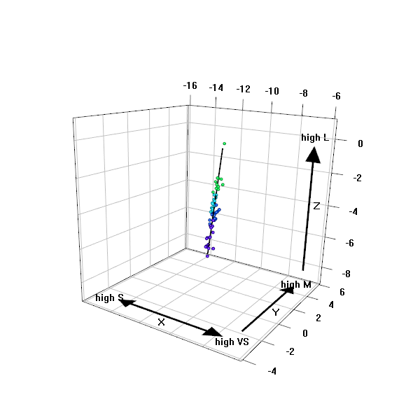

```r
#setting the limits for the xyz axes.
#Note that in order to keep uniform scaling of axes the range should be the same for each axis
lim.x<-c(-16, -6)
lim.y<-c(-4, 6)
lim.z<-c(-9,1)
#a scaffold to put axes on similar scales
plot3d(x=lim.x, y=lim.y, z=lim.z, type="n", aspect=TRUE, box=FALSE, xlab="", ylab="", zlab="")


plot3d(x=bt.pre$x[bt.pre$PC1q==1], y=bt.pre$y[bt.pre$PC1q==1], z=bt.pre$z[bt.pre$PC1q==1], type="s", radius=0.1, add=TRUE, col=col.pal[4])
plot3d(x=bt.pre$x[bt.pre$PC1q==2], y=bt.pre$y[bt.pre$PC1q==2], z=bt.pre$z[bt.pre$PC1q==2], type="s", radius=0.1, add=TRUE, col=col.pal[3])
plot3d(x=bt.pre$x[bt.pre$PC1q==3], y=bt.pre$y[bt.pre$PC1q==3], z=bt.pre$z[bt.pre$PC1q==3], type="s", radius=0.1, add=TRUE, col=col.pal[2])
plot3d(x=bt.pre$x[bt.pre$PC1q==4], y=bt.pre$y[bt.pre$PC1q==4], z=bt.pre$z[bt.pre$PC1q==4], type="s", radius=0.1, add=TRUE, col=col.pal[1])

#plots the PC1
plot3d(x=bt.pre$xPC1, y=bt.pre$yPC1, z=bt.pre$zPC1, type="l", lwd=2, add=TRUE, col="black")

#adding extra info to the graph
#X axis and arrowheads
segments3d(x=c(-14,-8), y=c(-3,-3), z=c(-9,-9), add=TRUE, lwd=3, add=TRUE)
triangles3d(x=c(-13.5,-13.5,-14.5), y=c(-2.5,-3.5,-3), z=c(-9,-9,-9), add=TRUE)
triangles3d(x=c(-8.5,-8.5,-7.5), y=c(-2.5,-3.5,-3), z=c(-9,-9,-9), add=TRUE)
texts3d(x=-7, y=-3, z=-9, texts="high VS")
texts3d(x=-15.1, y=-3, z=-9, texts="high S")
#X axis label
texts3d(x=-11, y=-3.5, z=-9, texts="X", font=1, cex=1.5)

#Y axis and arrowhead
segments3d(x=c(-7,-7), y=c(-2,4), z=c(-9,-9), add=TRUE, lwd=3, add=TRUE)
triangles3d(x=c(-6.5,-7.5,-7), y=c(3.5,3.5,4.5), z=c(-9,-9,-9), add=TRUE)
text3d(x=-7, y=5.1, z=-9, texts="high M")
#Y axis label
texts3d(x=-6.5, y=1, z=-9, texts="Y", font=1, cex=1.5)

#Z axis and arrowhead
segments3d(x=c(-7,-7), y=c(6,6), z=c(-8.5,-1), add=TRUE, lwd=3, add=TRUE)
triangles3d(x=c(-6.5,-7.5,-7), y=c(6,6,6), z=c(-1.5,-1.5,-0.5), add=TRUE)
text3d(x=-7, y=6, z=0.1, texts="high L")
texts3d(x=-6.5, y=6, z=-4, texts="Z", cex=1.5)

#adds a grid
grid3d(c("x","y+","z"))
```

## 5.5 Post-manipulation data

Having assessed the natural variation in blue tit crown coloration we now import the post-manipulation reflectance spectra for both treatments (UV(-) and UV(+)).

```r
#importing the experimental colour data
#UV(+)
bt.plus.ref<-read.csv("SuppInf_7_bt.post1.crw.csv")

#UV(-)
bt.minus.ref<-read.csv("SuppInf_8_bt.post2.crw.csv")
```

Computing xyz coordinates with the same settings as above:

```r
bt.plus<-as.data.frame(tetra(bt.plus.ref, Tetra=bt.sens, pcones=c(0.3743842,0.7093596,1,1), Irr=Irr5nm, irrIrr=2, wlInclude=TRUE))

bt.minus<-as.data.frame(tetra(bt.minus.ref, Tetra=bt.sens, pcones=c(0.3743842,0.7093596,1,1), Irr=Irr5nm, irrIrr=2, wlInclude=TRUE))
```

Some basic univariate descriptors for pre-manipulation, UV(+) and UV(-) males

```r
library(Rmisc)

summary(bt.pre[, c('x', 'y', 'z')])
```

```
       x                y                z
 Min.   :-12.15   Min.   :-0.823   Min.   :-6.196
 1st Qu.:-11.31   1st Qu.: 0.611   1st Qu.:-4.677
 Median :-11.07   Median : 1.513   Median :-4.057
 Mean   :-10.95   Mean   : 1.343   Mean   :-4.031
 3rd Qu.:-10.46   3rd Qu.: 2.140   3rd Qu.:-3.376
 Max.   : -9.59   Max.   : 4.090   Max.   :-0.711
```

```r
CI(bt.pre$x)
```

```
 upper   mean  lower
-10.81 -10.94 -11.08
```

```r
CI(bt.pre$y)
```

```
upper  mean lower
1.619 1.343 1.068
```

```r
CI(bt.pre$z)
```

```
 upper   mean  lower
-3.751 -4.031 -4.311
```

```r
summary(bt.plus[, c('x', 'y', 'z')])
```

```
       x               y              z
 Min.   :-12.0   Min.   :1.73   Min.   :-4.020
 1st Qu.:-11.6   1st Qu.:2.51   1st Qu.:-3.401
 Median :-11.4   Median :2.77   Median :-3.006
 Mean   :-11.4   Mean   :2.91   Mean   :-2.745
 3rd Qu.:-11.2   3rd Qu.:3.14   3rd Qu.:-2.163
 Max.   :-11.0   Max.   :4.65   Max.   :-0.554
```

```r
CI(bt.plus$x)
```

```
 upper   mean  lower
-11.33 -11.44 -11.55
```

```r
CI(bt.plus$y)
```

```
upper  mean lower
3.172 2.912 2.653
```

```r
CI(bt.plus$z)
```

```
 upper   mean  lower
-2.401 -2.745 -3.088
```

```r
summary(bt.minus[, c('x', 'y', 'z')])
```

```
       x               y               z
 Min.   :-13.6   Min.   :0.658   Min.   :-5.92
 1st Qu.:-12.9   1st Qu.:1.568   1st Qu.:-4.52
 Median :-12.6   Median :2.090   Median :-3.34
 Mean   :-12.5   Mean   :2.179   Mean   :-3.55
 3rd Qu.:-12.2   3rd Qu.:2.912   3rd Qu.:-2.61
 Max.   :-11.1   Max.   :3.559   Max.   :-1.98
```

```r
CI(bt.minus$x)
```

```
 upper   mean  lower
-12.29 -12.50 -12.72
```

```r
CI(bt.minus$y)
```

```
upper  mean lower
2.487 2.179 1.872
```

```r
CI(bt.minus$z)
```

```
upper  mean lower
-3.13 -3.55 -3.97
```

## 5.6 Plotting reflectance spectra and xyz coordinates

First, we compare reflectance spectra

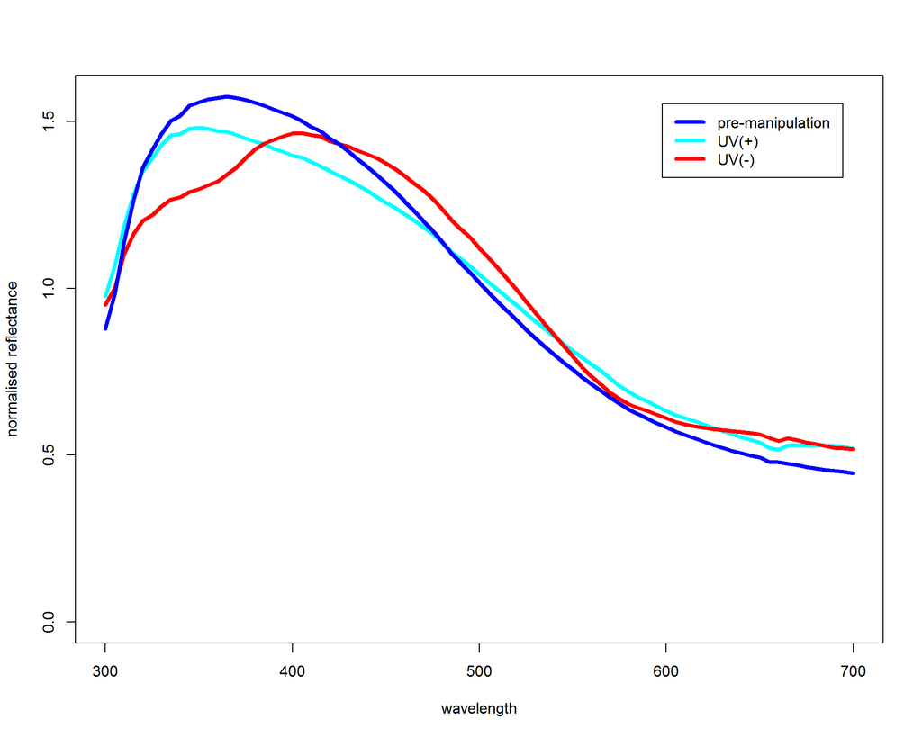

```r
#reflectance spectra for premanipulation and treatments
spectra.plus<-colMeans(bt.plus[,14:94])
spectra.minus<-colMeans(bt.minus[,14:94])

spectra.pre<-colMeans(bt.pre[,14:94])

wavelength<-seq(300,700, by=5)


#finds the max reflectance to adjust ylim automatically
ymax<-max(I(spectra.plus/mean(spectra.plus)), I(spectra.minus/mean(spectra.minus)), I(spectra.pre/mean(spectra.pre)))

plot(I(spectra.plus/mean(spectra.plus))~wavelength, ylim=c(0, ymax), xlab="wavelength", ylab="normalised reflectance", pch=0, col="white", bg="grey")
par(fig=c(0,1,0,1), new=TRUE)
lines(loess(I(spectra.plus/mean(spectra.plus))~wavelength, span=1), ylim=c(0, ymax), xlab="wavelength", ylab="normalised reflectance", lwd=4, col="cyan",)
par(fig=c(0,1,0,1), new=TRUE)
lines(loess(I(spectra.minus/mean(spectra.minus))~wavelength, span=1), ylim=c(0, ymax), xlab="wavelength", ylab="normalised reflectance", lwd=4, col="red")
par(fig=c(0,1,0,1), new=TRUE)
lines(loess(I(spectra.pre/mean(spectra.pre))~wavelength, span=1), ylim=c(0, ymax), xlab="wavelength", ylab="normalised reflectance", lwd=4, col="blue")
legend("topright", inset=0.05,  c("pre-manipulation", "UV(+)", "UV(-)"), lwd=c(4, 4, 4), col=c("blue", "cyan","red"))
```

Then we plot pre- and post-manipulation colours in visual space (note that colours correspond to average spectra above).

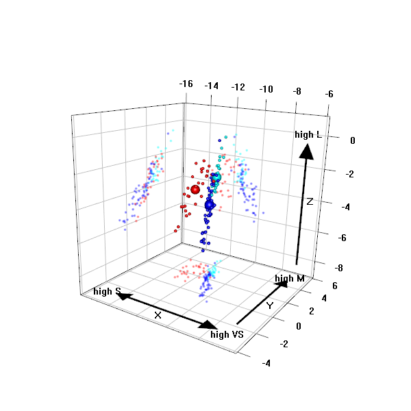

```r
#setting the limits for the xyz axes.
#Note that in order to keep uniform scaling of axes the range should be the same for each axis
lim.x<-c(-16, -6)
lim.y<-c(-4, 6)
lim.z<-c(-9,1)
#a scaffold to put axes on similar scales
plot3d(x=lim.x, y=lim.y, z=lim.z, type="n", aspect=TRUE, box=FALSE, xlab="", ylab="", zlab="")

plot3d(x=bt.pre$x, y=bt.pre$y, z=bt.pre$z, type="s", radius=0.1, add=TRUE, col="blue")
plot3d(x=mean(bt.pre$x), y=mean(bt.pre$y), z=mean(bt.pre$z), type="s", radius=0.3, add=TRUE, col="blue")

plot3d(x=bt.plus$x, y=bt.plus$y, z=bt.plus$z, type="s", radius=0.1, add=TRUE, col="cyan")
plot3d(x=mean(bt.plus$x), y=mean(bt.plus$y), z=mean(bt.plus$z), type="s", radius=0.3, add=TRUE, col="cyan")

plot3d(x=bt.minus$x, y=bt.minus$y, z=bt.minus$z, type="s", radius=0.1, add=TRUE, col="red")
plot3d(x=mean(bt.minus$x), y=mean(bt.minus$y), z=mean(bt.minus$z), type="s", radius=0.3, add=TRUE, col="red")

#adding some "shadows" on the walls
plot3d(x=bt.pre$x, y=bt.pre$y, z=min(lim.z), type="p", radius=0.1, add=TRUE, col="blue", alpha=0.5)
plot3d(x=min(lim.x), y=bt.pre$y, z=bt.pre$z, type="p", radius=0.1, add=TRUE, col="blue", alpha=0.5)
plot3d(x=bt.pre$x, y=max(lim.y), z=bt.pre$z, type="p", radius=0.1, add=TRUE, col="blue", alpha=0.5)

plot3d(x=bt.plus$x, y=bt.plus$y, z=min(lim.z), type="p", radius=0.1, add=TRUE, col="cyan", alpha=0.5)
plot3d(x=min(lim.x), y=bt.plus$y, z=bt.plus$z, type="p", radius=0.1, add=TRUE, col="cyan", alpha=0.5)
plot3d(x=bt.plus$x, y=max(lim.y), z=bt.plus$z, type="p", radius=0.1, add=TRUE, col="cyan", alpha=0.5)

plot3d(x=bt.minus$x, y=bt.minus$y, z=min(lim.z), type="p", radius=0.1, add=TRUE, col="red", alpha=0.5)
plot3d(x=min(lim.x), y=bt.minus$y, z=bt.minus$z, type="p", radius=0.1, add=TRUE, col="red", alpha=0.5)
plot3d(x=bt.minus$x, y=max(lim.y), z=bt.minus$z, type="p", radius=0.1, add=TRUE, col="red", alpha=0.5)

#adding extra info to the graph
#X axis and arrowheads
segments3d(x=c(-14,-8), y=c(-3,-3), z=c(-9,-9), add=TRUE, lwd=3, add=TRUE)
triangles3d(x=c(-13.5,-13.5,-14.5), y=c(-2.5,-3.5,-3), z=c(-9,-9,-9), add=TRUE)
triangles3d(x=c(-8.5,-8.5,-7.5), y=c(-2.5,-3.5,-3), z=c(-9,-9,-9), add=TRUE)
texts3d(x=-7, y=-3, z=-9, texts="high VS")
texts3d(x=-15.1, y=-3, z=-9, texts="high S")
#X axis label
texts3d(x=-11, y=-3.5, z=-9, texts="X", font=1, cex=1.5)

#Y axis and arrowhead
segments3d(x=c(-7,-7), y=c(-2,4), z=c(-9,-9), add=TRUE, lwd=3, add=TRUE)
triangles3d(x=c(-6.5,-7.5,-7), y=c(3.5,3.5,4.5), z=c(-9,-9,-9), add=TRUE)
text3d(x=-7, y=5.1, z=-9, texts="high M")
#Y axis label
texts3d(x=-6.5, y=1, z=-9, texts="Y", font=1, cex=1.5)

#Z axis and arrowhead
segments3d(x=c(-7,-7), y=c(6,6), z=c(-8.5,-1), add=TRUE, lwd=3, add=TRUE)
triangles3d(x=c(-6.5,-7.5,-7), y=c(6,6,6), z=c(-1.5,-1.5,-0.5), add=TRUE)
text3d(x=-7, y=6, z=0.1, texts="high L")
texts3d(x=-6.5, y=6, z=-4, texts="Z", cex=1.5)

#adds a grid
grid3d(c("x","y+","z"))
```

Note that in this figure, large symbols correspond to the centroid of each group (joint xyz mean).“Shadows” on the sides allow a better comparison of chromatic variation along xyz axes.

## 5.7 Comparing centroids

Finally, we can compare the centroids between groups. A multivariate comparison of means is usually done with the Hotelling test (T^2 ) (Johnson and Wichern 2007). This test, however, assumes multivariate normality of all groups and, crucially, similar covariance matrices between groups.These assumptions can be somewhat relaxed for large samples but do apply to the modest sample sizes in our case (Johnson and Wichern 2007).

*Multivariate normality* There are various tests for multivariate normality. Simulation studies (Farrell et al. 2007) suggest that three test perform well to detect departures from normality: Royston’s test (which is the equivalent to the univariate Shapiro-Wilk test), Henze-Zirkler’s test (which measures the distance between two distribution functions) and Mardia’s test (which tests for multivariate skewness and kurtosis). All these can be carried out with the package “MVN” (Korkmaz and Goksuluk 2014). Visual assessment of normality is also important and Q-Q plots are also provided in “MVN”.

Royston’s test

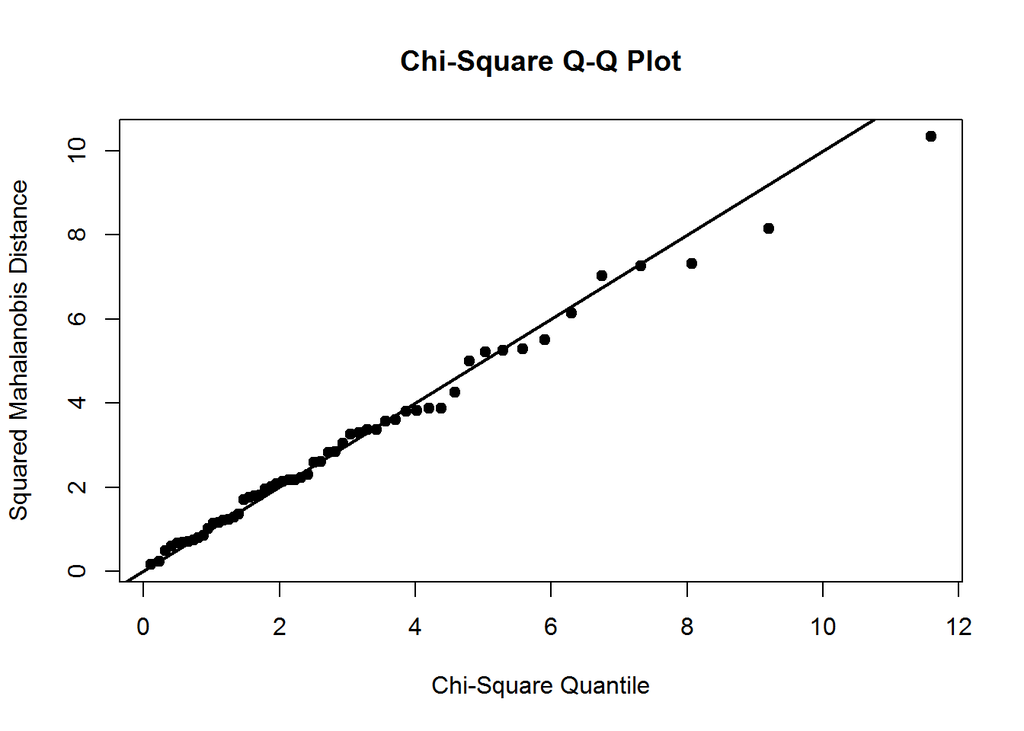

```
  Royston's Multivariate Normality Test
---------------------------------------------
  data : bt.pre[, c("x", "y", "z")]

  H       : 2.16
  p-value : 0.1656

  Result  : Data is multivariate normal.
---------------------------------------------
```

```r
require(MVN)
#pre-manipulation colour
roystonTest(data=bt.pre[,c('x','y','z')], qqplot=TRUE)
```

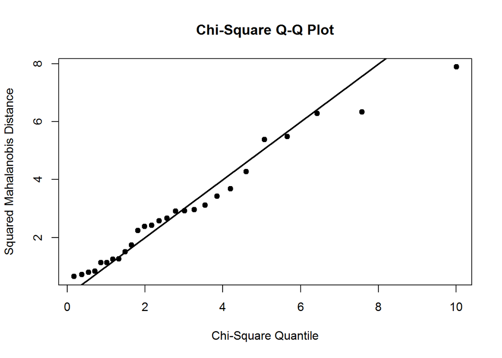

```
  Royston's Multivariate Normality Test
---------------------------------------------
  data : bt.plus[, c("x", "y", "z")]

  H       : 4.371
  p-value : 0.09109

  Result  : Data is multivariate normal.
---------------------------------------------
```

```r
#UV(+) treatment
roystonTest(data=bt.plus[,c('x','y','z')], qqplot=TRUE)
```

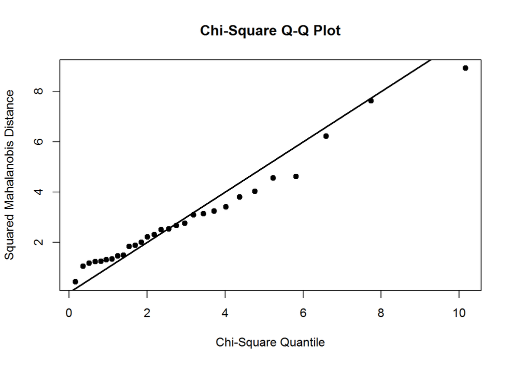

```
  Royston's Multivariate Normality Test
---------------------------------------------
  data : bt.minus[, c("x", "y", "z")]

  H       : 2.345
  p-value : 0.4397

  Result  : Data is multivariate normal.
---------------------------------------------
```

```r
#UV(-) treatment
roystonTest(data=bt.minus[,c('x','y','z')], qqplot=TRUE)
```

Henze-Zirkler’s test

```r
require(MVN)
#pre-manipulation colour
hzTest(data=bt.pre[,c('x','y','z')], qqplot=FALSE) #qqplot=FALSE to avoid repeating the graphs above
```

```
  Henze-Zirkler's Multivariate Normality Test
---------------------------------------------
  data : bt.pre[, c("x", "y", "z")]

  HZ      : 0.8503
  p-value : 0.1158

  Result  : Data is multivariate normal.
---------------------------------------------
```

```r
#UV(+) treatment
hzTest(data=bt.plus[,c('x','y','z')], qqplot=FALSE)
```

```
  Henze-Zirkler's Multivariate Normality Test
---------------------------------------------
  data : bt.plus[, c("x", "y", "z")]

  HZ      : 0.7203
  p-value : 0.1918

  Result  : Data is multivariate normal.
---------------------------------------------
```

```r
#UV(-) treatment
hzTest(data=bt.minus[,c('x','y','z')], qqplot=FALSE)
```

```
  Henze-Zirkler's Multivariate Normality Test
---------------------------------------------
  data : bt.minus[, c("x", "y", "z")]

  HZ      : 0.5726
  p-value : 0.5633

  Result  : Data is multivariate normal.
---------------------------------------------
```

Mardia’s test

```r
require(MVN)
#pre-manipulation colour
mardiaTest(data=bt.pre[,c('x','y','z')], qqplot=FALSE) #qqplot=FALSE to avoid repeating the graphs above
```

```
   Mardia's Multivariate Normality Test
---------------------------------------
   data : bt.pre[, c("x", "y", "z")]

   g1p            : 0.8488
   chi.skew       : 7.923
   p.value.skew   : 0.6364

   g2p            : 13.96
   z.kurtosis     : -0.7115
   p.value.kurt   : 0.4768

   chi.small.skew : 8.573
   p.value.small  : 0.5731

   Result         : Data is multivariate normal.
---------------------------------------
```

```r
#UV(+) treatment
mardiaTest(data=bt.plus[,c('x','y','z')], qqplot=FALSE)
```

```
   Mardia's Multivariate Normality Test
---------------------------------------
   data : bt.plus[, c("x", "y", "z")]

   g1p            : 1.575
   chi.skew       : 7.089
   p.value.skew   : 0.717

   g2p            : 12.92
   z.kurtosis     : -0.9848
   p.value.kurt   : 0.3247

   chi.small.skew : 8.323
   p.value.small  : 0.5973

   Result         : Data is multivariate normal.
---------------------------------------
```

```r
#UV(-) treatment
mardiaTest(data=bt.minus[,c('x','y','z')], qqplot=FALSE)
```

```
   Mardia's Multivariate Normality Test
---------------------------------------
   data : bt.minus[, c("x", "y", "z")]

   g1p            : 1.149
   chi.skew       : 5.555
   p.value.skew   : 0.8512

   g2p            : 13.04
   z.kurtosis     : -0.9646
   p.value.kurt   : 0.3347

   chi.small.skew : 6.452
   p.value.small  : 0.776

   Result         : Data is multivariate normal.
---------------------------------------
```

Inspection of Q-Q plots and test results suggest that the groups do not depart substantially from multivariate normality.

*Equality of covariance matrices* Equality of covariance matrices can be tested with Box’s M test although this test is believed to be very sensitive to small differences in covariance structure. This test can be implemented with the function “cov.Mtest” written by Michail Tsagris and found in Appendix 1.

This test requires the data (xyz coordinates) and a numeric vector identifying the groups. We bind pre-manipulation with UV(+) and UV(-) xyz coordiantes respectively and create a vector indicating group (1=pre-manipulation, 2=UV(+) or UV(-)).

Comparing pre-manipulation with UV(+) covariance matrices

```r
#data
bt.pre.plus<-rbind(bt.pre[,c("x", "y", "z")],bt.plus[,c("x", "y", "z")])
#numeric vector indicating group (1=pre-manipulation, 2=UV(+))
treat.pre.plus<-c(rep(1, length(bt.pre[,1])), rep(2, length(bt.plus[,1])))
#test
cov.Mtest(x=bt.pre.plus, ina=treat.pre.plus)
```

```
$M.test
[1] 12.48

$degrees
[1] 6

$critical
[1] 12.59

$p.value
[1] 0.05206
```

Comparing pre-manipulation with UV(-) covariance matrices

```r
#data
bt.pre.minus<-rbind(bt.pre[,c("x", "y", "z")],bt.minus[,c("x", "y", "z")])
#numeric vector indicating group (1=pre-manipulation, 2=UV(-))
treat.pre.minus<-c(rep(1, length(bt.pre[,1])), rep(2, length(bt.minus[,1])))
#test
cov.Mtest(x=bt.pre.minus, ina=treat.pre.minus)
```

```
$M.test
[1] 88.39

$degrees
[1] 6

$critical
[1] 12.59

$p.value
[1] 1.11e-16
```

Comparing UV(+) with UV(-) covariance matrices

```r
#data
bt.plus.minus<-rbind(bt.plus[,c("x", "y", "z")],bt.minus[,c("x", "y", "z")])
#numeric vector indicating group (1=UV(+), 2=UV(-))
treat.plus.minus<-c(rep(1, length(bt.plus[,1])), rep(2, length(bt.minus[,1])))
#test
cov.Mtest(x=bt.plus.minus, ina=treat.plus.minus)
```

```
$M.test
[1] 54.2

$degrees
[1] 6

$critical
[1] 12.59

$p.value
[1] 6.728e-10
```

The results suggest that the covariance matrices differ, in particular UV(-) from pre-manipulation and UV(+). However, Box’s M test is notorious for its sensitivity. Thus, it has been recommended that if sample sizes are equal the results from the test should be disregarded (Tabachnick and Fidell 2007) because these multivariate tests are robust. However, if sample sizes are unequal and Box’s M test shows p<0.001 one has to compare the variances and covariances between groups. If the groups with the largest sample sizes show higher variances and covariances then the test is robust, if it is the other way around the difference in covariance matrices can be problematic and alternatives are needed.

Given that we do have unequal sample sizes between groups and that comparing the UV(-) covariance matrices with UV(+) and pre-manipulation yields p-values for Box’s M test below 0.001 we should have a look at the covariance matrices.

```r
#Covariance matrices
cov(bt.pre[,c("x", "y", "z")])
```

```
        x       y       z
x  0.2633 -0.4944 -0.3887
y -0.4944  1.0551  0.9640
z -0.3887  0.9640  1.0932
```

```r
cov(bt.plus[,c("x", "y", "z")])
```

```
         x       y        z
x  0.08020 -0.1515 -0.09783
y -0.15154  0.4306  0.46996
z -0.09783  0.4700  0.75455
```

```r
cov(bt.minus[,c("x", "y", "z")])
```

```
         x        y      z
x  0.32155 -0.03912 0.2013
y -0.03912  0.65453 0.7624
z  0.20132  0.76244 1.2201
```

The covariance matrices show that variances for x and z are higher for the UV(-) treatment compared to pre-manipulation. Some of these differences can be visualised in a scatterplot matrix.

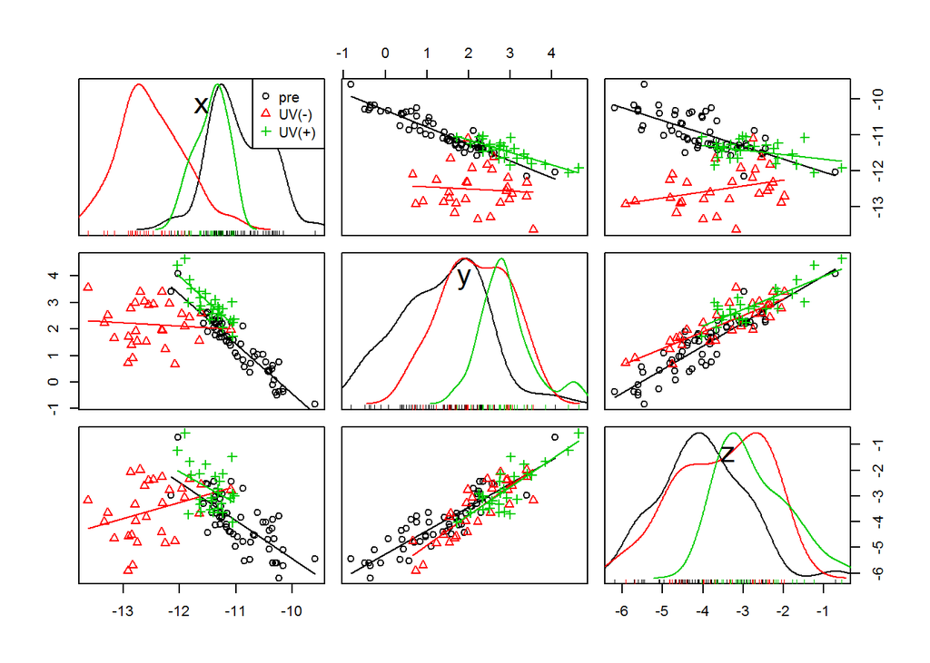

```r
#Scatterplot matrix
require(car)
#combine all first
bt.all<-rbind(bt.pre[,c("x", "y", "z")], bt.plus[,c("x", "y", "z")], bt.minus[,c("x", "y", "z")])
treat.all<-c(rep("pre",56), rep("UV(+)", 27), rep("UV(-)",29))

scatterplotMatrix(bt.all[,c("x", "y", "z")],smooth=FALSE, groups=treat.all, by.groups=TRUE)
```

Summarizing, our data shows multivariate normality but UV(-) has a different covariance matrix than pre-manipulation or UV(+). This may preclude the use of Hotelling’s test. There are two alternatives (Johnson and Wichern 2007) which can be computed using the function “meanTest” from Appendix 1. The first alternative (test=“chisq”, pp. 291-293 in Johnson and Wichern (2007)), which applies to large sample sizes, does not assume multivariate normality nor equality of variances; while the second one (test=“approx”, pp. 294-296 in Johnson and Wichern (2007)), which can be used with smaller sample sizes (as are ours here), requires multivariate normality but not equality of covariance matrices. The latter is equivalent to the Welch solution of comparing univariate means between two populations with different variances.

Here for the sake of this tutorial we run all three alternatives of the test (“hotelling”, “chisq” and “approx”), although the latter is the one that is probably better suited to our data. Note that in addition to the test statistics the function returns the multivariate differences in xyz and their associated 95% CIs.

Pre-manipulation versus UV(+)

```r
#remember loading function "meanTest" into workspace
meanTest(bt.plus[,c("x", "y", "z")], bt.pre[,c("x", "y", "z")], test="hotelling")
```

```
$test
[1] "hotelling"

$alpha
[1] 0.05

$df
num den
  3  79

$critical_value
[1] 8.367

$T2_stat
[1] 164.6

$p_value
[1] 0

$simultaneous_CI
  MeanSet1 MeanSet2    Diff   Lower   Upper
x  -11.441  -10.945 -0.4963 -0.8028 -0.1898
y    2.912    1.343  1.5688  0.9422  2.1953
z   -2.745   -4.031  1.2860  0.6135  1.9584
```

```r
meanTest(bt.plus[,c("x", "y", "z")], bt.pre[,c("x", "y", "z")], test="chisq")
```

```
$test
[1] "chisq"

$alpha
[1] 0.05

$df
[1] 3

$critical_value
[1] 7.815

$T2_stat
[1] 174.8

$p_value
[1] 0

$simultaneous_CI
  MeanSet1 MeanSet2    Diff   Lower   Upper
x  -11.441  -10.945 -0.4963 -0.7411 -0.2514
y    2.912    1.343  1.5688  1.0474  2.0902
z   -2.745   -4.031  1.2860  0.6769  1.8950
```

```r
meanTest(bt.plus[,c("x", "y", "z")], bt.pre[,c("x", "y", "z")], test="approx")
```

```
$test
[1] "approx"

$alpha
[1] 0.05

$df
  num   den
 3.00 61.53

$critical_value
[1] 8.531

$T2_stat
[1] 174.8

$p_value
[1] 0

$simultaneous_CI
  MeanSet1 MeanSet2    Diff   Lower   Upper
x  -11.441  -10.945 -0.4963 -0.7521 -0.2404
y    2.912    1.343  1.5688  1.0240  2.1136
z   -2.745   -4.031  1.2860  0.6496  1.9223
```

Pre-manipulation versus UV(-)

```r
meanTest(bt.minus[,c("x", "y", "z")], bt.pre[,c("x", "y", "z")], test="hotelling")
```

```
$test
[1] "hotelling"

$alpha
[1] 0.05

$df
num den
  3  81

$critical_value
[1] 8.353

$T2_stat
[1] 296.4

$p_value
[1] 0

$simultaneous_CI
  MeanSet1 MeanSet2    Diff   Lower  Upper
x  -12.504  -10.945 -1.5595 -1.9112 -1.208
y    2.179    1.343  0.8360  0.2018  1.470
z   -3.550   -4.031  0.4803 -0.2244  1.185
```

```r
meanTest(bt.minus[,c("x", "y", "z")], bt.pre[,c("x", "y", "z")], test="chisq")
```

```
$test
[1] "chisq"

$alpha
[1] 0.05

$df
[1] 3

$critical_value
[1] 7.815

$T2_stat
[1] 220.5

$p_value
[1] 0

$simultaneous_CI
  MeanSet1 MeanSet2    Diff   Lower  Upper
x  -12.504  -10.945 -1.5595 -1.9108 -1.208
y    2.179    1.343  0.8360  0.2672  1.405
z   -3.550   -4.031  0.4803 -0.2134  1.174
```

```r
meanTest(bt.minus[,c("x", "y", "z")], bt.pre[,c("x", "y", "z")], test="approx")
```

```
$test
[1] "approx"

$alpha
[1] 0.05

$df
  num   den
 3.00 50.23

$critical_value
[1] 8.701

$T2_stat
[1] 220.5

$p_value
[1] 0

$simultaneous_CI
  MeanSet1 MeanSet2    Diff   Lower  Upper
x  -12.504  -10.945 -1.5595 -1.9302 -1.189
y    2.179    1.343  0.8360  0.2358  1.436
z   -3.550   -4.031  0.4803 -0.2517  1.212
```

UV(+) versus UV(-)

```r
meanTest(bt.plus[,c("x", "y", "z")], bt.minus[,c("x", "y", "z")], test="hotelling")
```

```
$test
[1] "hotelling"

$alpha
[1] 0.05

$df
num den
  3  52

$critical_value
[1] 8.669

$T2_stat
[1] 222.2

$p_value
[1] 0

$simultaneous_CI
  MeanSet1 MeanSet2   Diff   Lower Upper
x  -11.441  -12.504 1.0633 0.70646 1.420
y    2.912    2.179 0.7327 0.15054 1.315
z   -2.745   -3.550 0.8056 0.01985 1.591
```

```r
meanTest(bt.plus[,c("x", "y", "z")], bt.minus[,c("x", "y", "z")], test="chisq")
```

```
$test
[1] "chisq"

$alpha
[1] 0.05

$df
[1] 3

$critical_value
[1] 7.815

$T2_stat
[1] 234.1

$p_value
[1] 0

$simultaneous_CI
  MeanSet1 MeanSet2   Diff   Lower Upper
x  -11.441  -12.504 1.0633 0.73182 1.395
y    2.912    2.179 0.7327 0.18410 1.281
z   -2.745   -3.550 0.8056 0.06593 1.545
```

```r
meanTest(bt.plus[,c("x", "y", "z")], bt.minus[,c("x", "y", "z")], test="approx")
```

```
$test
[1] "approx"

$alpha
[1] 0.05

$df
  num   den
 3.00 47.82

$critical_value
[1] 8.748

$T2_stat
[1] 234.1

$p_value
[1] 0

$simultaneous_CI
  MeanSet1 MeanSet2   Diff   Lower Upper
x  -11.441  -12.504 1.0633 0.71259 1.414
y    2.912    2.179 0.7327 0.15228 1.313
z   -2.745   -3.550 0.8056 0.02303 1.588
```

# 6 References

Bennett, A.T.D., Cuthill, I.C., Partridge, J.C. & Hart, N.S. (2000) Visual pigments, oil droplets, ocular media and cone photoreceptor distribution in two species of passerine bird: the blue tit ( Parus caeruleus L.) and the blackbird ( Turdus merula L.). Journal of Comparative Physiology A: Neuroethology, Sensory, Neural, and Behavioral Physiology, 186, 375-387.

Cassey, P., Ewen, J., Blackburn, T., Hauber, M., Vorobyev, M. & Marshall, N. (2008) Eggshell colour does not predict measures of maternal investment in eggs of Turdus thrushes. Naturwissenschaften, 95, 713-721.

Govardovskii, V.I., Fyhrquist, N., Reuter, T., Kuzmin, D.G. & Donner, K. (2000) In search of the visual pigment template. Visual Neuroscience, 17, 509-528.

Maia, R., Eliason, C.M., Bitton, P.-P., Doucet, S.M. & Shawkey, M.D. (2013a) pavo: an R package for the analysis, visualization and organization of spectral data (ed A Tatem). Methods in Ecology and Evolution, 4, 906-913.

Peters, A., Denk, A.G., Delhey, K. & Kempenaers, B. (2004) Carotenoid-based bill colour as an indicator of immunocompetence and sperm performance in male mallards. Journal of Evolutionary Biology, 17, 1111-1120.

Siddiqi, A., Cronin, T.W., Loew, E.R., Vorobyev, M. & Summers, K. (2004) Interspecific and intraspecific views of color signals in the strawberry poison frog Dendrobates pumilio. J Exp Biol, 207, 2471-2485.

Sillman, a J., Govardovskii, V.I., Röhlich, P., Southard, J. a & Loew, E.R. (1997) The photoreceptors and visual pigments of the garter snake (Thamnophis sirtalis): a microspectrophotometric, scanning electron microscopic and immunocytochemical study. Journal of comparative physiology. A, Sensory, neural, and behavioral physiology, 181, 89-101.

Stuart-Fox, D., Moussalli, A. & Whiting, M.J. (2008) Predator-specific camouflage in chameleons. Biology Letters, 4, 326-329.

Vorobyev, M. & Osorio, D. (1998) Receptor noise as a determinant of colour thresholds. Proceedings of the Royal Society B: Biological Sciences, 265, 351-358.

Vorobyev, M., Osorio, D., Bennett, A.T.D., Marshall, N.J. & Cuthill, I.C. (1998) Tetrachromacy, oil droplets and bird plumage colours. Journal of Comparative Physiology A-Sensory Neural & Behavioral Physiology, 183, 621-633.